# Analyses: Postfire Climate

Anna Talucci

July 20, 2019

# Overview

Rethinking of compounding factors associated with seedling success or failure in a postfire climate.

Climate/weather variables:

- Monthly preciptiation PPT01-PPt12
- Monthly Number of frost-free days NFFD01-NFFD12
- Monthly Precipitation as snow PAS01-PAS12
- Hargreaves climatic moisture deficit (mm) CMD01-CMD12 (CMD)

Climate data runs for the calendar year January through December. Because we are interested in post fire we will compile our own data set from the BC climate monthly variable data. We calculate one year post-fire from Octorber through September.

# Packages

The following Packages are required for the below analyses: library(gmodels) library(REdaS)

```r
library(dplyr)
library(tidyr)
library(ggplot2)
library(MASS)
library(car)
library(lme4)
library(DHARMa)
library(lsmeans)
library(RColorBrewer)
library(cowplot)
library(mosaic)
library(DT)
```

# Organize Climate Data

We will read in data by calendar year, combine, into one data frame, and calculate one-year post-fire values.

## 2016 BC Climate data

```r
c2016 = read.csv("../data/2016_climate.csv", header=TRUE, sep = ",", strip.white = TRUE)
head(c2016)
```

```
##   plot   ID1     ID2 Latitude Longitude Elevation Tmax01 Tmax02 Tmax03
## 1    1 site1 region1 53.26237 -125.4866       937   -2.4    3.7    7.2
## 2    2 site2 region2 53.27523 -125.4787      1039   -2.5    3.0    7.1
## 3    3 site3 region3 53.27626 -125.4778      1043   -2.5    3.0    7.1
## 4    4 site4 region4 53.27285 -125.4850      1025   -2.5    3.1    7.2
## 5    5 site5 region5 53.27042 -125.4812       989   -2.4    3.4    7.3
## 6    6 site6 region6 53.27745 -125.4909      1028   -2.5    3.1    7.2
##   Tmax04 Tmax05 Tmax06 Tmax07 Tmax08 Tmax09 Tmax10 Tmax11 Tmax12 Tmin01
## 1   11.6   15.0   18.4   20.8   21.8   15.6    8.5    3.3   -6.5  -11.7
## 2   11.3   14.6   17.8   20.2   21.3   15.1    8.0    3.2   -6.4  -11.4
## 3   11.3   14.6   17.8   20.2   21.2   15.1    8.0    3.2   -6.4  -11.4
## 4   11.4   14.7   17.9   20.3   21.3   15.2    8.1    3.2   -6.4  -11.4
## 5   11.5   14.8   18.1   20.5   21.5   15.4    8.2    3.3   -6.4  -11.5
## 6   11.4   14.7   17.8   20.3   21.3   15.2    8.1    3.2   -6.4  -11.4
##   Tmin02 Tmin03 Tmin04 Tmin05 Tmin06 Tmin07 Tmin08 Tmin09 Tmin10 Tmin11
```

[output cut: 160 more lines]

```r
c2016 = c2016 %>%
   dplyr::select(plot:Longitude, PPT01:PPT12, NFFD01:PAS12, CMD01:CMD12)
```

```r
names(c2016)[4:53] = c("lat", "long", "PPT01.2016", "PPT02.2016", "PPT03.2016", "PPT04.2016", "PPT05.2016", "PPT06.2016", "PPT07.2016", "PPT08.2016", "PPT09.2016", "PPT10.2016", "PPT11.2016", "PPT12.2016", "NFFD01.2016", "NFFD02.2016", "NFFD03.2016", "NFFD04.2016", "NFFD05.2016", "NFFD06.2016", "NFFD07.2016", "NFFD08.2016", "NFFD09.2016", "NFFD10.2016", "NFFD11.2016", "NFFD12.2016", "PAS01.2016", "PAS02.2016", "PAS03.2016", "PAS04.2016", "PAS05.2016", "PAS06.2016", "PAS07.2016", "PAS08.2016", "PAS09.2016", "PAS10.2016", "PAS11.2016", "PAS12.2016", "CMD01.2016", "CMD02.2016", "CMD03.2016", "CMD04.2016", "CMD05.2016", "CMD06.2016", "CMD07.2016", "CMD08.2016", "CMD09.2016", "CMD10.2016", "CMD11.2016", "CMD12.2016")

head(c2016)
```

```
##   plot   ID1     ID2      lat      long PPT01.2016 PPT02.2016 PPT03.2016
## 1    1 site1 region1 53.26237 -125.4866         48         39         37
## 2    2 site2 region2 53.27523 -125.4787         48         39         37
## 3    3 site3 region3 53.27626 -125.4778         48         39         37
## 4    4 site4 region4 53.27285 -125.4850         48         39         37
## 5    5 site5 region5 53.27042 -125.4812         48         39         37
## 6    6 site6 region6 53.27745 -125.4909         48         39         37
##   PPT04.2016 PPT05.2016 PPT06.2016 PPT07.2016 PPT08.2016 PPT09.2016
## 1         22         13         47         39         39         43
## 2         22         13         49         39         39         44
## 3         22         13         49         39         39         44
## 4         22         13         49         39         39         44
## 5         22         13         48         39         39         44
## 6         23         13         50         39         39         45
##   PPT10.2016 PPT11.2016 PPT12.2016 NFFD01.2016 NFFD02.2016 NFFD03.2016
```

[output cut: 48 more lines]

### 2015 BC Climate data

```r
c2015 = read.csv("../data/2015_climate.csv", header=TRUE, sep = ",", strip.white = TRUE)
head(c2015)
```

```
##   plot   ID1     ID2 Latitude Longitude Elevation Tmax01 Tmax02 Tmax03
## 1    1 site1 region1 53.26237 -125.4866       937   -0.8    2.8    7.4
## 2    2 site2 region2 53.27523 -125.4787      1039   -0.9    2.1    7.3
## 3    3 site3 region3 53.27626 -125.4778      1043   -0.9    2.0    7.3
## 4    4 site4 region4 53.27285 -125.4850      1025   -0.9    2.2    7.3
## 5    5 site5 region5 53.27042 -125.4812       989   -0.8    2.5    7.4
## 6    6 site6 region6 53.27745 -125.4909      1028   -0.9    2.1    7.3
##   Tmax04 Tmax05 Tmax06 Tmax07 Tmax08 Tmax09 Tmax10 Tmax11 Tmax12 Tmin01
## 1    9.1   16.7   20.3   22.9   22.1   14.5   10.9    0.3   -3.3   -9.9
## 2    8.8   16.3   19.7   22.3   21.5   14.0   10.4    0.1   -3.2   -9.6
## 3    8.8   16.3   19.6   22.3   21.5   14.0   10.4    0.1   -3.2   -9.6
## 4    8.8   16.3   19.8   22.4   21.6   14.1   10.5    0.2   -3.2   -9.6
## 5    8.9   16.5   20.0   22.6   21.8   14.3   10.6    0.2   -3.2   -9.7
## 6    8.8   16.3   19.7   22.3   21.6   14.1   10.5    0.1   -3.2   -9.6
##   Tmin02 Tmin03 Tmin04 Tmin05 Tmin06 Tmin07 Tmin08 Tmin09 Tmin10 Tmin11
```

[output cut: 160 more lines]

```r
c2015 = c2015 %>%
   dplyr::select(plot:Longitude, PPT01:PPT12, NFFD01:PAS12, CMD01:CMD12)
```

```r
names(c2015)[4:53] = c("lat", "long", "PPT01.2015", "PPT02.2015", "PPT03.2015", "PPT04.2015", "PPT05.2015", "PPT06.2015", "PPT07.2015", "PPT08.2015", "PPT09.2015", "PPT10.2015", "PPT11.2015", "PPT12.2015", "NFFD01.2015", "NFFD02.2015", "NFFD03.2015", "NFFD04.2015", "NFFD05.2015", "NFFD06.2015", "NFFD07.2015", "NFFD08.2015", "NFFD09.2015", "NFFD10.2015", "NFFD11.2015", "NFFD12.2015", "PAS01.2015", "PAS02.2015", "PAS03.2015", "PAS04.2015", "PAS05.2015", "PAS06.2015", "PAS07.2015", "PAS08.2015", "PAS09.2015", "PAS10.2015", "PAS11.2015", "PAS12.2015", "CMD01.2015", "CMD02.2015", "CMD03.2015", "CMD04.2015", "CMD05.2015", "CMD06.2015", "CMD07.2015", "CMD08.2015", "CMD09.2015", "CMD10.2015", "CMD11.2015", "CMD12.2015")
```

### 2014 BC Climate data

```r
c2014 = read.csv("../data/2014_climate.csv", header=TRUE, sep = ",", strip.white = TRUE)
head(c2014)
```

```
##   plot   ID1     ID2 Latitude Longitude Elevation Tmax01 Tmax02 Tmax03
## 1    1 site1 region1 53.26237 -125.4866       937   -1.3   -4.0    2.0
## 2    2 site2 region2 53.27523 -125.4787      1039   -1.4   -4.7    1.9
## 3    3 site3 region3 53.27626 -125.4778      1043   -1.4   -4.8    1.8
## 4    4 site4 region4 53.27285 -125.4850      1025   -1.4   -4.6    1.9
## 5    5 site5 region5 53.27042 -125.4812       989   -1.3   -4.3    2.0
## 6    6 site6 region6 53.27745 -125.4909      1028   -1.4   -4.7    1.9
##   Tmax04 Tmax05 Tmax06 Tmax07 Tmax08 Tmax09 Tmax10 Tmax11 Tmax12 Tmin01
## 1    8.8   14.4   18.2   22.9   22.6   18.4   10.5    0.1   -2.2  -10.9
## 2    8.5   14.0   17.6   22.3   22.1   17.9   10.1   -0.1   -2.2  -10.6
## 3    8.5   14.0   17.6   22.3   22.0   17.9   10.1   -0.1   -2.2  -10.5
## 4    8.6   14.0   17.7   22.4   22.1   18.0   10.1    0.0   -2.2  -10.6
## 5    8.7   14.2   17.9   22.6   22.3   18.2   10.3    0.0   -2.2  -10.7
## 6    8.6   14.0   17.7   22.4   22.1   18.0   10.1   -0.1   -2.2  -10.6
##   Tmin02 Tmin03 Tmin04 Tmin05 Tmin06 Tmin07 Tmin08 Tmin09 Tmin10 Tmin11
```

[output cut: 160 more lines]

```r
c2014 = c2014 %>%
   dplyr::select(plot:Longitude, PPT01:PPT12, NFFD01:PAS12, CMD01:CMD12)
```

```r
names(c2014)[4:53] = c("lat", "long", "PPT01.2014", "PPT02.2014", "PPT03.2014", "PPT04.2014", "PPT05.2014", "PPT06.2014", "PPT07.2014", "PPT08.2014", "PPT09.2014", "PPT10.2014", "PPT11.2014", "PPT12.2014", "NFFD01.2014", "NFFD02.2014", "NFFD03.2014", "NFFD04.2014", "NFFD05.2014", "NFFD06.2014", "NFFD07.2014", "NFFD08.2014", "NFFD09.2014", "NFFD10.2014", "NFFD11.2014", "NFFD12.2014", "PAS01.2014", "PAS02.2014", "PAS03.2014", "PAS04.2014", "PAS05.2014", "PAS06.2014", "PAS07.2014", "PAS08.2014", "PAS09.2014", "PAS10.2014", "PAS11.2014", "PAS12.2014", "CMD01.2014", "CMD02.2014", "CMD03.2014", "CMD04.2014", "CMD05.2014", "CMD06.2014", "CMD07.2014", "CMD08.2014", "CMD09.2014", "CMD10.2014", "CMD11.2014", "CMD12.2014")
```

### 2013 BC Climate data

```r
c2013 = read.csv("../data/2013_climate.csv", header=TRUE, sep = ",", strip.white = TRUE)
head(c2013)
```

```
##   plot   ID1     ID2 Latitude Longitude Elevation Tmax01 Tmax02 Tmax03
## 1    1 site1 region1 53.26237 -125.4866       937   -3.2    1.5    5.1
## 2    2 site2 region2 53.27523 -125.4787      1039   -3.3    0.8    5.0
## 3    3 site3 region3 53.27626 -125.4778      1043   -3.3    0.8    5.0
## 4    4 site4 region4 53.27285 -125.4850      1025   -3.3    1.0    5.0
## 5    5 site5 region5 53.27042 -125.4812       989   -3.2    1.2    5.1
## 6    6 site6 region6 53.27745 -125.4909      1028   -3.3    0.9    5.0
##   Tmax04 Tmax05 Tmax06 Tmax07 Tmax08 Tmax09 Tmax10 Tmax11 Tmax12 Tmin01
## 1    7.8   14.7   18.2   22.6   21.9   18.4   10.4    1.0   -4.4  -13.7
## 2    7.5   14.2   17.6   22.0   21.3   17.9    9.9    0.8   -4.3  -13.4
## 3    7.5   14.2   17.6   22.0   21.3   17.9    9.9    0.8   -4.3  -13.3
## 4    7.6   14.3   17.7   22.1   21.4   18.0   10.0    0.9   -4.3  -13.4
## 5    7.7   14.5   17.9   22.3   21.6   18.2   10.1    1.0   -4.3  -13.5
## 6    7.6   14.3   17.7   22.0   21.4   18.0    9.9    0.8   -4.3  -13.4
##   Tmin02 Tmin03 Tmin04 Tmin05 Tmin06 Tmin07 Tmin08 Tmin09 Tmin10 Tmin11
```

[output cut: 160 more lines]

```r
c2013 = c2013 %>%
   dplyr::select(plot:Longitude, PPT01:PPT12, NFFD01:PAS12, CMD01:CMD12)
```

```r
names(c2013)[4:53] = c("lat", "long", "PPT01.2013", "PPT02.2013", "PPT03.2013", "PPT04.2013", "PPT05.2013", "PPT06.2013", "PPT07.2013", "PPT08.2013", "PPT09.2013", "PPT10.2013", "PPT11.2013", "PPT12.2013", "NFFD01.2013", "NFFD02.2013", "NFFD03.2013", "NFFD04.2013", "NFFD05.2013", "NFFD06.2013", "NFFD07.2013", "NFFD08.2013", "NFFD09.2013", "NFFD10.2013", "NFFD11.2013", "NFFD12.2013", "PAS01.2013", "PAS02.2013", "PAS03.2013", "PAS04.2013", "PAS05.2013", "PAS06.2013", "PAS07.2013", "PAS08.2013", "PAS09.2013", "PAS10.2013", "PAS11.2013", "PAS12.2013", "CMD01.2013", "CMD02.2013", "CMD03.2013", "CMD04.2013", "CMD05.2013", "CMD06.2013", "CMD07.2013", "CMD08.2013", "CMD09.2013", "CMD10.2013", "CMD11.2013", "CMD12.2013")
```

### 2012 BC Climate data

```r
c2012 = read.csv("../data/2012_climate.csv", header=TRUE, sep = ",", strip.white = TRUE)
head (c2012)
```

```
##   plot   ID1     ID2 Latitude Longitude Elevation Tmax01 Tmax02 Tmax03
## 1    1 site1 region1 53.26237 -125.4866       937   -4.2    0.4    3.5
## 2    2 site2 region2 53.27523 -125.4787      1039   -4.3   -0.3    3.4
## 3    3 site3 region3 53.27626 -125.4778      1043   -4.3   -0.3    3.4
## 4    4 site4 region4 53.27285 -125.4850      1025   -4.3   -0.2    3.5
## 5    5 site5 region5 53.27042 -125.4812       989   -4.2    0.1    3.5
## 6    6 site6 region6 53.27745 -125.4909      1028   -4.3   -0.2    3.5
##   Tmax04 Tmax05 Tmax06 Tmax07 Tmax08 Tmax09 Tmax10 Tmax11 Tmax12 Tmin01
## 1    8.6   12.6   16.2   21.6   21.4   18.2    8.3    1.3   -4.6  -14.2
## 2    8.3   12.2   15.6   21.0   20.8   17.7    7.8    1.1   -4.5  -13.9
## 3    8.3   12.2   15.6   21.0   20.8   17.7    7.8    1.1   -4.5  -13.9
## 4    8.3   12.3   15.7   21.1   20.9   17.8    7.9    1.2   -4.5  -13.9
## 5    8.4   12.4   15.9   21.3   21.1   17.9    8.0    1.2   -4.5  -14.0
## 6    8.3   12.3   15.6   21.1   20.9   17.7    7.8    1.1   -4.5  -13.9
##   Tmin02 Tmin03 Tmin04 Tmin05 Tmin06 Tmin07 Tmin08 Tmin09 Tmin10 Tmin11
```

[output cut: 160 more lines]

```r
c2012 = c2012 %>%
   dplyr::select(plot:Longitude, PPT01:PPT12, NFFD01:PAS12, CMD01:CMD12)
```

```r
names(c2012)[4:53] = c("lat", "long", "PPT01.2012", "PPT02.2012", "PPT03.2012", "PPT04.2012", "PPT05.2012", "PPT06.2012", "PPT07.2012", "PPT08.2012", "PPT09.2012", "PPT10.2012", "PPT11.2012", "PPT12.2012", "NFFD01.2012", "NFFD02.2012", "NFFD03.2012", "NFFD04.2012", "NFFD05.2012", "NFFD06.2012", "NFFD07.2012", "NFFD08.2012", "NFFD09.2012", "NFFD10.2012", "NFFD11.2012", "NFFD12.2012", "PAS01.2012", "PAS02.2012", "PAS03.2012", "PAS04.2012", "PAS05.2012", "PAS06.2012", "PAS07.2012", "PAS08.2012", "PAS09.2012", "PAS10.2012", "PAS11.2012", "PAS12.2012", "CMD01.2012", "CMD02.2012", "CMD03.2012", "CMD04.2012", "CMD05.2012", "CMD06.2012", "CMD07.2012", "CMD08.2012", "CMD09.2012", "CMD10.2012", "CMD11.2012", "CMD12.2012")
```

### Merge climate data

```r
climate.1213 = merge(c2012, c2013, by = c("plot", "ID1", "ID2", "lat", "long"))
head(climate.1213)
```

```
##   plot    ID1      ID2      lat      long PPT01.2012 PPT02.2012 PPT03.2012
## 1    1  site1  region1 53.26237 -125.4866         67         24         40
## 2   10 site10 region10 53.27037 -125.4747         67         24         40
## 3   11 site11 region11 53.26726 -125.4772         67         24         40
## 4   12 site12 region12 53.26872 -125.4877         67         24         40
## 5   13 site13 region13 53.27042 -125.4890         67         24         40
## 6   14 site14 region14 53.27383 -125.4792         67         24         40
##   PPT04.2012 PPT05.2012 PPT06.2012 PPT07.2012 PPT08.2012 PPT09.2012
## 1         15         29         75         36         27         16
## 2         15         29         77         36         27         16
## 3         15         29         77         36         27         16
## 4         16         29         77         36         27         16
## 5         16         29         78         36         27         17
## 6         15         29         78         36         27         17
##   PPT10.2012 PPT11.2012 PPT12.2012 NFFD01.2012 NFFD02.2012 NFFD03.2012
```

[output cut: 104 more lines]

```r
climate.1415 = merge(c2014, c2015, by = c("plot", "ID1", "ID2", "lat", "long"))
head(climate.1415)
```

```
##   plot    ID1      ID2      lat      long PPT01.2014 PPT02.2014 PPT03.2014
## 1    1  site1  region1 53.26237 -125.4866         42         36         39
## 2   10 site10 region10 53.27037 -125.4747         42         36         39
## 3   11 site11 region11 53.26726 -125.4772         42         36         39
## 4   12 site12 region12 53.26872 -125.4877         42         36         39
## 5   13 site13 region13 53.27042 -125.4890         42         36         39
## 6   14 site14 region14 53.27383 -125.4792         42         36         39
##   PPT04.2014 PPT05.2014 PPT06.2014 PPT07.2014 PPT08.2014 PPT09.2014
## 1         24         31         42         45         23         32
## 2         24         31         44         45         24         32
## 3         24         31         43         45         24         32
## 4         24         31         44         45         24         33
## 5         24         31         44         46         24         33
## 6         24         31         44         45         24         33
##   PPT10.2014 PPT11.2014 PPT12.2014 NFFD01.2014 NFFD02.2014 NFFD03.2014
```

[output cut: 104 more lines]

```r
climate.12131415 = merge(climate.1213, climate.1415, by = c("plot", "ID1", "ID2", "lat", "long"))
head(climate.12131415)
```

```
##   plot    ID1      ID2      lat      long PPT01.2012 PPT02.2012 PPT03.2012
## 1    1  site1  region1 53.26237 -125.4866         67         24         40
## 2   10 site10 region10 53.27037 -125.4747         67         24         40
## 3   11 site11 region11 53.26726 -125.4772         67         24         40
## 4   12 site12 region12 53.26872 -125.4877         67         24         40
## 5   13 site13 region13 53.27042 -125.4890         67         24         40
## 6   14 site14 region14 53.27383 -125.4792         67         24         40
##   PPT04.2012 PPT05.2012 PPT06.2012 PPT07.2012 PPT08.2012 PPT09.2012
## 1         15         29         75         36         27         16
## 2         15         29         77         36         27         16
## 3         15         29         77         36         27         16
## 4         16         29         77         36         27         16
## 5         16         29         78         36         27         17
## 6         15         29         78         36         27         17
##   PPT10.2012 PPT11.2012 PPT12.2012 NFFD01.2012 NFFD02.2012 NFFD03.2012
```

[output cut: 216 more lines]

```r
climate.1213141516 = merge(climate.12131415, c2016, by = c("plot", "ID1", "ID2", "lat", "long"))
head(climate.1213141516)
```

```
##   plot    ID1      ID2      lat      long PPT01.2012 PPT02.2012 PPT03.2012
## 1    1  site1  region1 53.26237 -125.4866         67         24         40
## 2   10 site10 region10 53.27037 -125.4747         67         24         40
## 3   11 site11 region11 53.26726 -125.4772         67         24         40
## 4   12 site12 region12 53.26872 -125.4877         67         24         40
## 5   13 site13 region13 53.27042 -125.4890         67         24         40
## 6   14 site14 region14 53.27383 -125.4792         67         24         40
##   PPT04.2012 PPT05.2012 PPT06.2012 PPT07.2012 PPT08.2012 PPT09.2012
## 1         15         29         75         36         27         16
## 2         15         29         77         36         27         16
## 3         15         29         77         36         27         16
## 4         16         29         77         36         27         16
## 5         16         29         78         36         27         17
## 6         15         29         78         36         27         17
##   PPT10.2012 PPT11.2012 PPT12.2012 NFFD01.2012 NFFD02.2012 NFFD03.2012
```

[output cut: 272 more lines]

### Plot, fire name and fire year

```r
plotindex = read.csv("../data/plotindex_climate.csv", header=TRUE, sep = ",", strip.white = TRUE)
head(plotindex)
```

```
##   plot  MPB fire.severity utm_zone  UTM_E   UTM_N Elevation fire.event
## 1    1  low      moderate       10 334151 5904342       937  chelaslie
## 2    2  low      moderate       10 334730 5905754      1039  chelaslie
## 3    3  low           low       10 334790 5905867      1043  chelaslie
## 4    4 high      moderate       10 334297 5905505      1025  chelaslie
## 5    5  low          high       10 334541 5905225       989  chelaslie
## 6    6  low           low       10 333922 5906030      1028  chelaslie
##   fire.year      lat      long
## 1      2014 53.26237 -125.4866
## 2      2014 53.27523 -125.4787
## 3      2014 53.27626 -125.4778
## 4      2014 53.27285 -125.4850
## 5      2014 53.27042 -125.4812
## 6      2014 53.27745 -125.4909
```

## Merge Fire and climate data

```r
climate.plot = merge(plotindex, climate.1213141516, by = c("plot"))
head(climate.plot)
```

```
##   plot  MPB fire.severity utm_zone  UTM_E   UTM_N Elevation fire.event
## 1    1  low      moderate       10 334151 5904342       937  chelaslie
## 2    2  low      moderate       10 334730 5905754      1039  chelaslie
## 3    3  low           low       10 334790 5905867      1043  chelaslie
## 4    4 high      moderate       10 334297 5905505      1025  chelaslie
## 5    5  low          high       10 334541 5905225       989  chelaslie
## 6    6  low           low       10 333922 5906030      1028  chelaslie
##   fire.year    lat.x    long.x   ID1     ID2    lat.y    long.y PPT01.2012
## 1      2014 53.26237 -125.4866 site1 region1 53.26237 -125.4866         67
## 2      2014 53.27523 -125.4787 site2 region2 53.27523 -125.4787         67
## 3      2014 53.27626 -125.4778 site3 region3 53.27626 -125.4778         67
## 4      2014 53.27285 -125.4850 site4 region4 53.27285 -125.4850         67
## 5      2014 53.27042 -125.4812 site5 region5 53.27042 -125.4812         67
## 6      2014 53.27745 -125.4909 site6 region6 53.27745 -125.4909         67
##   PPT02.2012 PPT03.2012 PPT04.2012 PPT05.2012 PPT06.2012 PPT07.2012
```

[output cut: 279 more lines]

delete duplicate rows

```r
climate.plot = climate.plot %>%
   dplyr::select(plot:fire.year, lat.y:CMD12.2016)
head(climate.plot)
```

```
##   plot  MPB fire.severity utm_zone  UTM_E   UTM_N Elevation fire.event
## 1    1  low      moderate       10 334151 5904342       937  chelaslie
## 2    2  low      moderate       10 334730 5905754      1039  chelaslie
## 3    3  low           low       10 334790 5905867      1043  chelaslie
## 4    4 high      moderate       10 334297 5905505      1025  chelaslie
## 5    5  low          high       10 334541 5905225       989  chelaslie
## 6    6  low           low       10 333922 5906030      1028  chelaslie
##   fire.year    lat.y    long.y PPT01.2012 PPT02.2012 PPT03.2012 PPT04.2012
## 1      2014 53.26237 -125.4866         67         24         40         15
## 2      2014 53.27523 -125.4787         67         24         41         15
## 3      2014 53.27626 -125.4778         67         24         41         16
## 4      2014 53.27285 -125.4850         67         24         40         16
## 5      2014 53.27042 -125.4812         67         24         40         15
## 6      2014 53.27745 -125.4909         67         25         41         16
##   PPT05.2012 PPT06.2012 PPT07.2012 PPT08.2012 PPT09.2012 PPT10.2012
```

[output cut: 279 more lines]

Subset by fire

```r
chelaslie = climate.plot %>%
    dplyr::filter(fire.event == "chelaslie")
```

```r
entiako = climate.plot %>%
    dplyr::filter(fire.event == "entiako")
```

```r
tweedsmuir = climate.plot %>%
    dplyr::filter(fire.event == "tweedsmuir")
```

### Calculate variables

Climate/weather variables:

- Monthly preciptiation PPT01-PPt12
- Monthly Number of frost-free days NFFD01-NFFD12
- Monthly Precipitation as snow PAS01-PAS12
- Hargreaves climatic moisture deficit (mm) CMD01-CMD12

#### Variables for Tweedsmuir

Fire burned in 2013 September Post fire climate included October 2013 - September 2014

- Average precipitation 1-year post-fire
- Average frost free days 1-year post-fire
- Average precipitation as snow 1-year post-fire
- Average climate moisture deficit 1-year postfire

```r
tweedsmuir = tweedsmuir %>%
    mutate(sum_PPT_1314 = (PPT10.2013 + PPT11.2013 + PPT12.2013 + PPT01.2014 + PPT02.2014 + PPT03.2014 + PPT04.2014 + PPT05.2014 + PPT06.2014 + PPT07.2014 + PPT08.2014 + PPT09.2014)) %>%
    mutate(avg_PPT_1314 = sum_PPT_1314/12) %>%
    mutate(sum_NFFD_1314 = (NFFD10.2013 + NFFD11.2013 + NFFD12.2013 + NFFD01.2014 + NFFD02.2014 + NFFD03.2014 + NFFD04.2014 + NFFD05.2014 + NFFD06.2014 + NFFD07.2014 + NFFD08.2014 + NFFD09.2014)) %>%
    mutate(avg_NFFD_1314 = sum_NFFD_1314/12) %>%
    mutate(sum_PAS_1314 = (PAS10.2013 + PAS11.2013 + PAS12.2013 + PAS01.2014 + PAS02.2014 + PAS03.2014 + PAS04.2014 + PAS05.2014 + PAS06.2014 + PAS07.2014 + PAS08.2014 + PAS09.2014)) %>%
    mutate(avg_PAS_1314 = sum_PAS_1314/12) %>%
     mutate(sum_CMD_1314 = (CMD10.2013 + CMD11.2013 + CMD12.2013 + CMD01.2014 + CMD02.2014 + CMD03.2014 + CMD04.2014 + CMD05.2014 + CMD06.2014 + CMD07.2014 + CMD08.2014 + CMD09.2014)) %>%
    mutate(avg_CMD_1314 = sum_CMD_1314/12)
```

```r
tweedsmuir = tweedsmuir %>%
    dplyr::select(plot:long.y, sum_PPT_1314:avg_CMD_1314)
```

```r
names(tweedsmuir)[10:19] = c("lat", "long", "sum_PPT", "avg_PPT", "sum_NFFD", "avg_NFFD", "sum_PAS", "avg_PAS", "sum_CMD", "avg_CMD")
head(tweedsmuir)
```

```
##   plot      MPB fire.severity utm_zone  UTM_E   UTM_N Elevation fire.event
## 1   52 moderate      moderate        9 692861 5907193       966 tweedsmuir
## 2   53      LOW      moderate        9 692665 5907055       954 tweedsmuir
## 3   54     high           low        9 693377 5906833       950 tweedsmuir
## 4   55      low           low        9 693472 5906910       942 tweedsmuir
## 5   56      low          high        9 693076 5906911       947 tweedsmuir
## 6   57      low          high        9 692392 5906843       954 tweedsmuir
##   fire.year      lat      long sum_PPT  avg_PPT sum_NFFD avg_NFFD sum_PAS
## 1      2013 53.30770 -125.7101     438 36.50000      146 12.16667     194
## 2      2013 53.22228 -125.5183     423 35.25000      140 11.66667     195
## 3      2013 53.22613 -125.5143     421 35.08333      140 11.66667     195
## 4      2013 53.22485 -125.5166     421 35.08333      141 11.75000     195
## 5      2013 53.21369 -125.5291     424 35.33333      140 11.66667     197
## 6      2013 53.21319 -125.5322     425 35.41667      139 11.58333     197
##    avg_PAS sum_CMD  avg_CMD
## 1 16.16667     325 27.08333
## 2 16.25000     347 28.91667
## 3 16.25000     347 28.91667
## 4 16.25000     348 29.00000
## 5 16.41667     348 29.00000
## 6 16.41667     347 28.91667
```

#### Variables for Entiako

Fire burned in 2012 July Post fire climate included October 2012 - September 2013

- Average precipitation 1-year post-fire
- Average frost free days 1-year post-fire
- Average precipitation as snow 1-year post-fire
- Average climate moisture deficit 1-year post-fire

```r
entiako = entiako %>%
    mutate(sum_PPT_1213 = (PPT10.2012 + PPT11.2012 + PPT12.2012 + PPT01.2013 + PPT02.2013 + PPT03.2013 + PPT04.2013 + PPT05.2013 + PPT06.2013 + PPT07.2013 + PPT08.2013 + PPT09.2013)) %>%
    mutate(avg_PPT_1213 = sum_PPT_1213/12) %>%
    mutate(sum_NFFD_1213 = (NFFD10.2012 + NFFD11.2012 + NFFD12.2012 + NFFD01.2013 + NFFD02.2013 + NFFD03.2013 + NFFD04.2013 + NFFD05.2013 + NFFD06.2013 + NFFD07.2013 + NFFD08.2013 + NFFD09.2013)) %>%
    mutate(avg_NFFD_1213 = sum_NFFD_1213/12) %>%
    mutate(sum_PAS_1213 = (PAS10.2012 + PAS11.2012 + PAS12.2012 + PAS01.2013 + PAS02.2013 + PAS03.2013 + PAS04.2013 + PAS05.2013 + PAS06.2013 + PAS07.2013 + PAS08.2013 + PAS09.2013)) %>%
    mutate(avg_PAS_1213 = sum_PAS_1213/12) %>%
     mutate(sum_CMD_1213 = (CMD10.2012 + CMD11.2012 + CMD12.2012 + CMD01.2013 + CMD02.2013 + CMD03.2013 + CMD04.2013 + CMD05.2013 + CMD06.2013 + CMD07.2013 + CMD08.2013 + CMD09.2013)) %>%
    mutate(avg_CMD_1213 = sum_CMD_1213/12)
```

```r
entiako = entiako %>%
    dplyr::select(plot:long.y, sum_PPT_1213:avg_CMD_1213)
```

```r
names(entiako)[10:19] = c("lat", "long", "sum_PPT", "avg_PPT", "sum_NFFD", "avg_NFFD", "sum_PAS", "avg_PAS", "sum_CMD", "avg_CMD")
head(entiako)
```

```
##   plot      MPB fire.severity utm_zone  UTM_E   UTM_N Elevation fire.event
## 1   15     high      moderate       10 331883 5899958       949    entiako
## 2   16 moderate          high       10 332162 5900377       947    entiako
## 3   17 moderate      moderate       10 332007 5900240       944    entiako
## 4   20 moderate      moderate       10 331125 5899028       947    entiako
## 5   21      low          high       10 330916 5898980       952    entiako
## 6   22      low          high       10 331350 5898916       966    entiako
##   fire.year      lat      long sum_PPT  avg_PPT sum_NFFD avg_NFFD sum_PAS
## 1      2012 53.27743 -125.4805     434 36.16667      145 12.08333     183
## 2      2012 53.27170 -125.4867     435 36.25000      146 12.16667     183
## 3      2012 53.31577 -125.6913     425 35.41667      148 12.33333     182
## 4      2012 53.31849 -125.6957     425 35.41667      148 12.33333     182
## 5      2012 53.31966 -125.6971     425 35.41667      148 12.33333     182
## 6      2012 53.31611 -125.6967     426 35.50000      147 12.25000     182
##    avg_PAS sum_CMD  avg_CMD
## 1 15.25000     340 28.33333
## 2 15.25000     337 28.08333
## 3 15.16667     332 27.66667
## 4 15.16667     332 27.66667
## 5 15.16667     332 27.66667
## 6 15.16667     331 27.58333
```

#### Variables for chelaslie

- Average precipitation 1 year post fire
- Average frost free days 1 year post fire
- Average precipitation as snow 1 year post fire
- Average climate moisture deficit 1 year post fire

```r
chelaslie = chelaslie %>%
    mutate(sum_PPT_1415 = (PPT10.2014 + PPT11.2014 + PPT12.2014 + PPT01.2015 + PPT02.2015 + PPT03.2015 + PPT04.2015 + PPT05.2015 + PPT06.2015 + PPT07.2015 + PPT08.2015 + PPT09.2015)) %>%
    mutate(avg_PPT_1415 = sum_PPT_1415/12) %>%
    mutate(sum_NFFD_1415 = (NFFD10.2014 + NFFD11.2014 + NFFD12.2014 + NFFD01.2015 + NFFD02.2015 + NFFD03.2015 + NFFD04.2015 + NFFD05.2015 + NFFD06.2015 + NFFD07.2015 + NFFD08.2015 + NFFD09.2015)) %>%
    mutate(avg_NFFD_1415 = sum_NFFD_1415/12) %>%
    mutate(sum_PAS_1415 = (PAS10.2014 + PAS11.2014 + PAS12.2014 + PAS01.2015 + PAS02.2015 + PAS03.2015 + PAS04.2015 + PAS05.2015 + PAS06.2015 + PAS07.2015 + PAS08.2015 + PAS09.2015)) %>%
    mutate(avg_PAS_1415 = sum_PAS_1415/12) %>%
     mutate(sum_CMD_1415 = (CMD10.2014 + CMD11.2014 + CMD12.2014 + CMD01.2015 + CMD02.2015 + CMD03.2015 + CMD04.2015 + CMD05.2015 + CMD06.2015 + CMD07.2015 + CMD08.2015 + CMD09.2015)) %>%
    mutate(avg_CMD_1415 = sum_CMD_1415/12)
```

```r
chelaslie = chelaslie %>%
    dplyr::select(plot:long.y, sum_PPT_1415:avg_CMD_1415)
```

```r
names(chelaslie)[10:19] = c("lat", "long", "sum_PPT", "avg_PPT", "sum_NFFD", "avg_NFFD", "sum_PAS", "avg_PAS", "sum_CMD", "avg_CMD")
head(chelaslie)
```

```
##   plot  MPB fire.severity utm_zone  UTM_E   UTM_N Elevation fire.event
## 1    1  low      moderate       10 334151 5904342       937  chelaslie
## 2    2  low      moderate       10 334730 5905754      1039  chelaslie
## 3    3  low           low       10 334790 5905867      1043  chelaslie
## 4    4 high      moderate       10 334297 5905505      1025  chelaslie
## 5    5  low          high       10 334541 5905225       989  chelaslie
## 6    6  low           low       10 333922 5906030      1028  chelaslie
##   fire.year      lat      long sum_PPT  avg_PPT sum_NFFD avg_NFFD sum_PAS
## 1      2014 53.26237 -125.4866     476 39.66667      156 13.00000     184
## 2      2014 53.27523 -125.4787     482 40.16667      151 12.58333     192
## 3      2014 53.27626 -125.4778     482 40.16667      150 12.50000     194
## 4      2014 53.27285 -125.4850     484 40.33333      151 12.58333     190
## 5      2014 53.27042 -125.4812     479 39.91667      153 12.75000     187
## 6      2014 53.27745 -125.4909     487 40.58333      151 12.58333     194
##    avg_PAS sum_CMD  avg_CMD
## 1 15.33333     379 31.58333
## 2 16.00000     365 30.41667
## 3 16.16667     365 30.41667
## 4 15.83333     366 30.50000
## 5 15.58333     373 31.08333
## 6 16.16667     364 30.33333
```

### Merge fire event data

```r
postfire.weather = rbind(entiako, tweedsmuir, chelaslie)
```

Save to csv

Create frost event variable, as total number of days with frost, to use in analysis instead of frost free days

```r
postfire.weather = mutate(postfire.weather, frost.events = 365-sum_NFFD)
head(postfire.weather)
```

```
##   plot      MPB fire.severity utm_zone  UTM_E   UTM_N Elevation fire.event
## 1   15     high      moderate       10 331883 5899958       949    entiako
## 2   16 moderate          high       10 332162 5900377       947    entiako
## 3   17 moderate      moderate       10 332007 5900240       944    entiako
## 4   20 moderate      moderate       10 331125 5899028       947    entiako
## 5   21      low          high       10 330916 5898980       952    entiako
## 6   22      low          high       10 331350 5898916       966    entiako
##   fire.year      lat      long sum_PPT  avg_PPT sum_NFFD avg_NFFD sum_PAS
## 1      2012 53.27743 -125.4805     434 36.16667      145 12.08333     183
## 2      2012 53.27170 -125.4867     435 36.25000      146 12.16667     183
## 3      2012 53.31577 -125.6913     425 35.41667      148 12.33333     182
## 4      2012 53.31849 -125.6957     425 35.41667      148 12.33333     182
## 5      2012 53.31966 -125.6971     425 35.41667      148 12.33333     182
## 6      2012 53.31611 -125.6967     426 35.50000      147 12.25000     182
##    avg_PAS sum_CMD  avg_CMD frost.events
## 1 15.25000     340 28.33333          220
## 2 15.25000     337 28.08333          219
## 3 15.16667     332 27.66667          217
## 4 15.16667     332 27.66667          217
## 5 15.16667     332 27.66667          217
## 6 15.16667     331 27.58333          218
```

Select only plots that burned, remove unburned plots.

```r
postfire.weather = postfire.weather %>%
    dplyr::filter(fire.severity != "unburned")
```

# Topography data

```r
topo = read.csv("../data/field_aspect_slope.csv", header=TRUE, sep = ",", strip.white = TRUE)
head(topo)
```

```
##   plot aspect slope
## 1    1      0     5
## 2    2    155     0
## 3    3    165     2
## 4    4    168     5
## 5    5    227     0
## 6    6    264     5
```

Add topography to weather data.

```r
postfire.weather = merge(postfire.weather, topo, by = c("plot"))
head(postfire.weather)
```

```
##   plot  MPB fire.severity utm_zone  UTM_E   UTM_N Elevation fire.event
## 1    1  low      moderate       10 334151 5904342       937  chelaslie
## 2    2  low      moderate       10 334730 5905754      1039  chelaslie
## 3    3  low           low       10 334790 5905867      1043  chelaslie
## 4    4 high      moderate       10 334297 5905505      1025  chelaslie
## 5    5  low          high       10 334541 5905225       989  chelaslie
## 6    6  low           low       10 333922 5906030      1028  chelaslie
##   fire.year      lat      long sum_PPT  avg_PPT sum_NFFD avg_NFFD sum_PAS
## 1      2014 53.26237 -125.4866     476 39.66667      156 13.00000     184
## 2      2014 53.27523 -125.4787     482 40.16667      151 12.58333     192
## 3      2014 53.27626 -125.4778     482 40.16667      150 12.50000     194
## 4      2014 53.27285 -125.4850     484 40.33333      151 12.58333     190
## 5      2014 53.27042 -125.4812     479 39.91667      153 12.75000     187
## 6      2014 53.27745 -125.4909     487 40.58333      151 12.58333     194
##    avg_PAS sum_CMD  avg_CMD frost.events aspect slope
## 1 15.33333     379 31.58333          209      0     5
## 2 16.00000     365 30.41667          214    155     0
## 3 16.16667     365 30.41667          215    165     2
## 4 15.83333     366 30.50000          214    168     5
## 5 15.58333     373 31.08333          212    227     0
## 6 16.16667     364 30.33333          214    264     5
```

#### Calculate Heat Load

Following equation 3 outlined by McCune and Keon 2002 *Equations for potential annual direct incident radiation and heat load’ in the Journal of Vegetation Science

```
##   plot  MPB fire.severity utm_zone  UTM_E   UTM_N Elevation fire.event
## 1    1  low      moderate       10 334151 5904342       937  chelaslie
## 2    2  low      moderate       10 334730 5905754      1039  chelaslie
## 3    3  low           low       10 334790 5905867      1043  chelaslie
## 4    4 high      moderate       10 334297 5905505      1025  chelaslie
## 5    5  low          high       10 334541 5905225       989  chelaslie
## 6    6  low           low       10 333922 5906030      1028  chelaslie
##   fire.year      lat      long sum_PPT  avg_PPT sum_NFFD avg_NFFD sum_PAS
## 1      2014 53.26237 -125.4866     476 39.66667      156 13.00000     184
## 2      2014 53.27523 -125.4787     482 40.16667      151 12.58333     192
## 3      2014 53.27626 -125.4778     482 40.16667      150 12.50000     194
## 4      2014 53.27285 -125.4850     484 40.33333      151 12.58333     190
## 5      2014 53.27042 -125.4812     479 39.91667      153 12.75000     187
## 6      2014 53.27745 -125.4909     487 40.58333      151 12.58333     194
##    avg_PAS sum_CMD  avg_CMD frost.events aspect slope aspect_rad
## 1 15.33333     379 31.58333          209      0     5   0.000000
## 2 16.00000     365 30.41667          214    155     0   2.705260
## 3 16.16667     365 30.41667          215    165     2   2.879793
## 4 15.83333     366 30.50000          214    168     5   2.932153
## 5 15.58333     373 31.08333          212    227     0   3.961897
## 6 16.16667     364 30.33333          214    264     5   4.607669
##   foldaspect_rad  slope_rad lat_degrees   lat_rad  heatload
## 1     -0.7853982 0.08726646          53 0.9250245 0.7800685
## 2      1.9198622 0.00000000          53 0.9250245 0.8252665
## 3      2.0943951 0.03490659          53 0.9250245 0.8279182
## 4      2.1467550 0.08726646          53 0.9250245 0.8326532
## 5      3.1066861 0.00000000          53 0.9250245 0.8252665
## 6      2.4609142 0.08726646          53 0.9250245 0.8424206
```

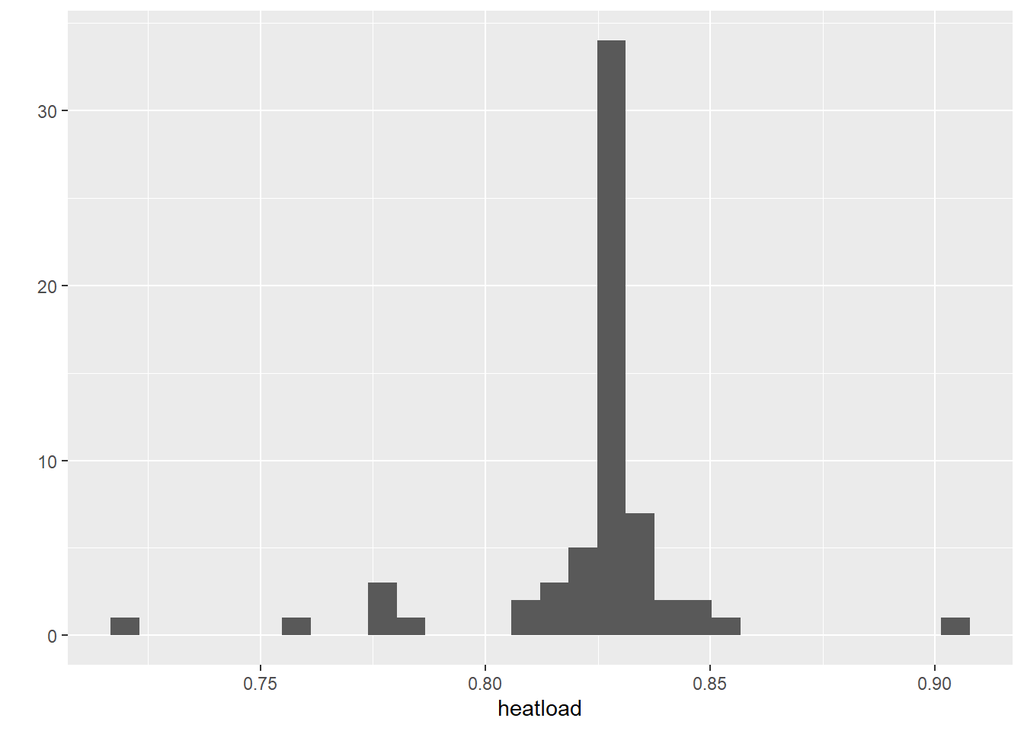

```r
postfire.weather = mutate(postfire.weather, aspect_rad = deg2rad(aspect))
postfire.weather = mutate(postfire.weather, foldaspect_rad = pi-abs(aspect_rad-(5*(pi)/4)))
postfire.weather = mutate(postfire.weather, slope_rad = deg2rad(slope))
postfire.weather = mutate(postfire.weather, lat_degrees = 53)
postfire.weather = mutate(postfire.weather, lat_rad = deg2rad(lat_degrees))
postfire.weather = mutate(postfire.weather, heatload = (0.339+0.808*cos(lat_rad)*cos(slope_rad)-0.196*sin(lat_rad)*sin(slope_rad)-0.482*cos(foldaspect_rad)*sin(slope_rad)))

head(postfire.weather)
```

# Seedling Data

```r
fire.seedeffort = read.csv("../data/chapter2_analysis34_seedlingeffort_11december2017.csv", header = TRUE, sep = ",", strip.white = TRUE)

head(fire.seedeffort)
```

```
##   plot seedling.ct seedling.area
## 1    1           3             4
## 2    2          68             4
## 3    3          15             4
## 4    4           6             4
## 5    5          15             4
## 6    6           0             4
```

```r
seedling.weather = merge(postfire.weather, fire.seedeffort, by = c("plot"))
head(seedling.weather)
```

```
##   plot  MPB fire.severity utm_zone  UTM_E   UTM_N Elevation fire.event
## 1    1  low      moderate       10 334151 5904342       937  chelaslie
## 2    2  low      moderate       10 334730 5905754      1039  chelaslie
## 3    3  low           low       10 334790 5905867      1043  chelaslie
## 4    4 high      moderate       10 334297 5905505      1025  chelaslie
## 5    5  low          high       10 334541 5905225       989  chelaslie
## 6    6  low           low       10 333922 5906030      1028  chelaslie
##   fire.year      lat      long sum_PPT  avg_PPT sum_NFFD avg_NFFD sum_PAS
## 1      2014 53.26237 -125.4866     476 39.66667      156 13.00000     184
## 2      2014 53.27523 -125.4787     482 40.16667      151 12.58333     192
## 3      2014 53.27626 -125.4778     482 40.16667      150 12.50000     194
## 4      2014 53.27285 -125.4850     484 40.33333      151 12.58333     190
## 5      2014 53.27042 -125.4812     479 39.91667      153 12.75000     187
## 6      2014 53.27745 -125.4909     487 40.58333      151 12.58333     194
##    avg_PAS sum_CMD  avg_CMD frost.events aspect slope aspect_rad
```

[output cut: 20 more lines]

# Canopy structure data

```r
fire = read.csv("../data/2018-09-20_ch2-burnedplots-wcodes-edit43.csv", header = TRUE, sep = ",", strip.white = TRUE)
head(fire)
```

```
##   plot   Plot_ID plot.mpb stems bom fire live upf no.canopy yes.canopy
## 1    1 CEC0629M1      LM1     7   0    7    0   0         0          7
## 2    2 CEC0630H1      LM2     7   0    7    0   0         0          7
## 3    3 CEC0701L1      LL3    42  17   21    3   1         4         38
## 4    4 CEC0702M1      HM4    12  12    0    0   0         0         12
## 5    5 CEC0702H1      LH5    24   0    9    0  15        15          9
## 6    6 CEC0703M1      LL6    20  16    4    0   0        10         10
##   no.seed yes.seed tot.stem cone.ct seed.density disturbance fire.type
## 1       0        7        7     282           75 beetle+fire  sev.surf
## 2       0        7        7    1150         1700 beetle+fire  sev.surf
## 3      28       14       42    3665          375 beetle+fire   surface
## 4       6        6       12    1286          150 beetle+fire  sev.surf
## 5      15        9       24    1585          375 beetle+fire     crown
## 6      15        5       20     680            2 beetle+fire   surface
##    burncon
## 1 moderate
## 2 moderate
## 3 moderate
## 4 moderate
## 5 moderate
## 6 moderate
```

```r
seedling.weather = merge(seedling.weather, fire, by = c("plot"))
head(seedling.weather)
```

```
##   plot  MPB fire.severity utm_zone  UTM_E   UTM_N Elevation fire.event
## 1    1  low      moderate       10 334151 5904342       937  chelaslie
## 2    2  low      moderate       10 334730 5905754      1039  chelaslie
## 3    3  low           low       10 334790 5905867      1043  chelaslie
## 4    4 high      moderate       10 334297 5905505      1025  chelaslie
## 5    5  low          high       10 334541 5905225       989  chelaslie
## 6    6  low           low       10 333922 5906030      1028  chelaslie
##   fire.year      lat      long sum_PPT  avg_PPT sum_NFFD avg_NFFD sum_PAS
## 1      2014 53.26237 -125.4866     476 39.66667      156 13.00000     184
## 2      2014 53.27523 -125.4787     482 40.16667      151 12.58333     192
## 3      2014 53.27626 -125.4778     482 40.16667      150 12.50000     194
## 4      2014 53.27285 -125.4850     484 40.33333      151 12.58333     190
## 5      2014 53.27042 -125.4812     479 39.91667      153 12.75000     187
## 6      2014 53.27745 -125.4909     487 40.58333      151 12.58333     194
##    avg_PAS sum_CMD  avg_CMD frost.events aspect slope aspect_rad
```

[output cut: 34 more lines]

### Calculate additional variables

```r
seedling.weather = mutate(seedling.weather, prop.bom = bom/stems)
seedling.weather = mutate(seedling.weather, prop.canopy = yes.canopy/stems)
seedling.weather = mutate(seedling.weather, prop.nocanopy = no.canopy/stems)
seedling.weather = mutate(seedling.weather, prop.opencone = yes.seed/stems)
seedling.weather = mutate(seedling.weather, prop.closedcone = no.seed/stems)
seedling.weather = mutate(seedling.weather, prop.cone.ct = cone.ct/stems)
```

```r
datatable(seedling.weather)
```

|  | plot | MPB | fire.severity | utm_zone | UTM_E | UTM_N | Elevation | fire.event | fire.year | lat | long | sum_PPT | avg_PPT | sum_NFFD | avg_NFFD | sum_PAS | avg_PAS | sum_CMD | avg_CMD | frost.events | aspect | slope | aspect_rad | foldaspect_rad | slope_rad | lat_degrees | lat_rad | heatload | seedling.ct | … |
| --- | --- | --- | --- | --- | --- | --- | --- | --- | --- | --- | --- | --- | --- | --- | --- | --- | --- | --- | --- | --- | --- | --- | --- | --- | --- | --- | --- | --- | --- | --- |
| 1 | 1 | low | moderate | 10 | 334151 | 5904342 | 937 | chelaslie | 2014 | 53.262365 | -125.48661 | 476 | 39.6666666666667 | 156 | 13 | 184 | 15.3333333333333 | 379 | 31.5833333333333 | 209 | 0 | 5 | 0 | -0.785398163397448 | 0.0872664625997165 | 53 | 0.925024503556995 | 0.780068539333662 | 3 | … |
| 2 | 2 | low | moderate | 10 | 334730 | 5905754 | 1039 | chelaslie | 2014 | 53.275226 | -125.478668 | 482 | 40.1666666666667 | 151 | 12.5833333333333 | 192 | 16 | 365 | 30.4166666666667 | 214 | 155 | 0 | 2.70526034059121 | 1.91986217719376 | 0 | 53 | 0.925024503556995 | 0.825266538706855 | 68 | … |
| 3 | 3 | low | low | 10 | 334790 | 5905867 | 1043 | chelaslie | 2014 | 53.27626 | -125.477829 | 482 | 40.1666666666667 | 150 | 12.5 | 194 | 16.1666666666667 | 365 | 30.4166666666667 | 215 | 165 | 2 | 2.87979326579064 | 2.0943951023932 | 0.0349065850398866 | 53 | 0.925024503556995 | 0.827918189414778 | 15 | … |
| 4 | 4 | high | moderate | 10 | 334297 | 5905505 | 1025 | chelaslie | 2014 | 53.272855 | -125.485023 | 484 | 40.3333333333333 | 151 | 12.5833333333333 | 190 | 15.8333333333333 | 366 | 30.5 | 214 | 168 | 5 | 2.93215314335047 | 2.14675497995303 | 0.0872664625997165 | 53 | 0.925024503556995 | 0.832653214450661 | 6 | … |
| 5 | 5 | low | high | 10 | 334541 | 5905225 | 989 | chelaslie | 2014 | 53.270417 | -125.481224 | 479 | 39.9166666666667 | 153 | 12.75 | 187 | 15.5833333333333 | 373 | 31.0833333333333 | 212 | 227 | 0 | 3.96189740202713 | 3.10668606854991 | 0 | 53 | 0.925024503556995 | 0.825266538706855 | 15 | … |
| 6 | 6 | low | low | 10 | 333922 | 5906030 | 1028 | chelaslie | 2014 | 53.277453 | -125.490921 | 487 | 40.5833333333333 | 151 | 12.5833333333333 | 194 | 16.1666666666667 | 364 | 30.3333333333333 | 214 | 264 | 5 | 4.60766922526503 | 2.46091424531201 | 0.0872664625997165 | 53 | 0.925024503556995 | 0.842420613735048 | 0 | … |
| 7 | 7 | high | high | 10 | 334510 | 5904882 | 960 | chelaslie | 2014 | 53.267327 | -125.481514 | 477 | 39.75 | 155 | 12.9166666666667 | 184 | 15.3333333333333 | 376 | 31.3333333333333 | 210 | 234 | 20 | 4.08407044966673 | 2.9845130209103 | 0.349065850398866 | 53 | 0.925024503556995 | 0.905227875927228 | 4 | … |
| 8 | 8 | moderate | high | 10 | 334391 | 5904692 | 949 | chelaslie | 2014 | 53.265583 | -125.483192 | 477 | 39.75 | 155 | 12.9166666666667 | 184 | 15.3333333333333 | 377 | 31.4166666666667 | 210 | 188 | 2 | 3.28121899374934 | 2.49582083035189 | 0.0349065850398866 | 53 | 0.925024503556995 | 0.832941703791884 | 6 | … |
| 9 | 9 | low | high | 10 | 335119 | 5904973 | 985 | chelaslie | 2014 | 53.268334 | -125.472435 | 476 | 39.6666666666667 | 154 | 12.8333333333333 | 186 | 15.5 | 374 | 31.1666666666667 | 211 | 146 | 2 | 2.54818070791172 | 1.76278254451427 | 0.0349065850398866 | 53 | 0.925024503556995 | 0.822717115179662 | 6 | … |
| 10 | 10 | low | high | 10 | 334978 | 5905205 | 997 | chelaslie | 2014 | 53.270373 | -125.47467 | 477 | 39.75 | 152 | 12.6666666666667 | 186 | 15.5 | 372 | 31 | 213 | 205 | 1 | 3.57792496658838 | 2.79252680319093 | 0.0174532925199433 | 53 | 0.925024503556995 | 0.830365358716716 | 5 | … |

[output cut: 53 more lines]

# Analayses

Due to a relatively small data set, we evaluated the influence of each climate variable with a separate statistical model

- Frost Event Model
- Snow accumulation Model
- CMD Model

## Model: Frost*Fire

```r
frostfire1 = glm.nb(seedling.ct ~ frost.events:fire.type + offset(log(seedling.area)), data = seedling.weather)
```

### Residuals

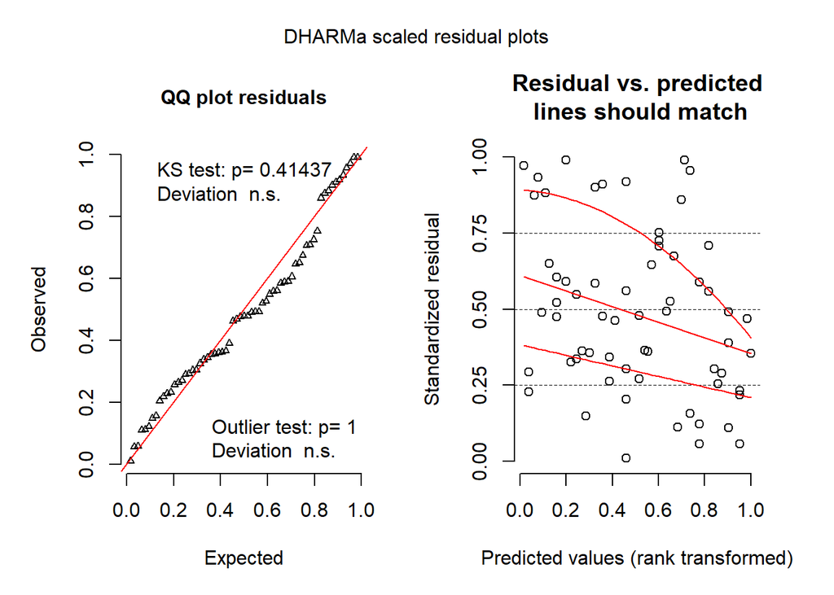

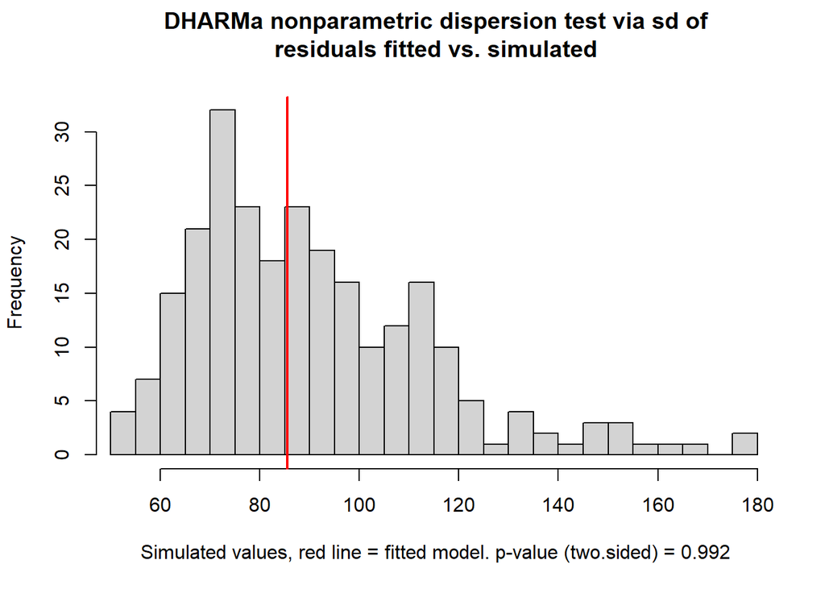

```
##
##  DHARMa nonparametric dispersion test via sd of residuals fitted
##  vs. simulated
##
## data:  simulationOutput
## ratioObsSim = 0.948, p-value = 0.992
## alternative hypothesis: two.sided
```

```r
testDispersion(frostfire1.res)
```

### Summary

```r
summary(frostfire1)
```

```
##
## Call:
## glm.nb(formula = seedling.ct ~ frost.events:fire.type + offset(log(seedling.area)),
##     data = seedling.weather, init.theta = 0.7238363269, link = log)
##
## Deviance Residuals:
##      Min        1Q    Median        3Q       Max
## -2.49411  -0.99047  -0.49986   0.03758   2.74502
##
## Coefficients:
##                                Estimate Std. Error z value Pr(>|z|)
## (Intercept)                     3.21839    4.30018   0.748    0.454
## frost.events:fire.typecrown    -0.01271    0.02012  -0.631    0.528
## frost.events:fire.typesev.surf -0.01189    0.02025  -0.587    0.557
## frost.events:fire.typesurface  -0.01573    0.02025  -0.777    0.437
##
## (Dispersion parameter for Negative Binomial(0.7238) family taken to be 1)
##
##     Null deviance: 79.703  on 62  degrees of freedom
## Residual deviance: 74.832  on 59  degrees of freedom
## AIC: 607.76
##
## Number of Fisher Scoring iterations: 1
##
##
##               Theta:  0.724
##           Std. Err.:  0.119
##
##  2 x log-likelihood:  -597.757
```

### Estimates

```r
( frostfire1.est = cbind(Estimate = coef(frostfire1), confint(frostfire1)))
```

```
##                                   Estimate       2.5 %      97.5 %
## (Intercept)                     3.21839375 -7.99672804 14.12583221
## frost.events:fire.typecrown    -0.01270596 -0.06402942  0.04057286
## frost.events:fire.typesev.surf -0.01188538 -0.06238007  0.04034788
## frost.events:fire.typesurface  -0.01573329 -0.06702267  0.03740323
```

```r
( exp(frostfire1.est))
```

```
##                                  Estimate       2.5 %       97.5 %
## (Intercept)                    24.9879510 0.000336562 1.363864e+06
## frost.events:fire.typecrown     0.9873744 0.937977404 1.041407e+00
## frost.events:fire.typesev.surf  0.9881850 0.939525731 1.041173e+00
## frost.events:fire.typesurface   0.9843898 0.935173998 1.038112e+00
```

```r
(frost_estimate=exp(coef(frostfire1)))
```

```
##                    (Intercept)    frost.events:fire.typecrown
##                     24.9879510                      0.9873744
## frost.events:fire.typesev.surf  frost.events:fire.typesurface
##                      0.9881850                      0.9843898
```

```r
(frost_lcl_ucl=exp(confint(frostfire1)))
```

```
##                                      2.5 %       97.5 %
## (Intercept)                    0.000336562 1.363864e+06
## frost.events:fire.typecrown    0.937977404 1.041407e+00
## frost.events:fire.typesev.surf 0.939525731 1.041173e+00
## frost.events:fire.typesurface  0.935173998 1.038112e+00
```

```r
(frost_p_value=summary(frostfire1)$coefficients[,4] )
```

```
##                    (Intercept)    frost.events:fire.typecrown
##                      0.4541993                      0.5277679
## frost.events:fire.typesev.surf  frost.events:fire.typesurface
##                      0.5573190                      0.4372223
```

### Predict Frost*Fire

```r
preddat.frostfire1 = data.frame(frost.events = seedling.weather$frost.events, fire.type = factor(seedling.weather$fire.type), seedling.area = 100)

head(preddat.frostfire1)
```

```
##   frost.events fire.type seedling.area
## 1          209  sev.surf           100
## 2          214  sev.surf           100
## 3          215   surface           100
## 4          214  sev.surf           100
## 5          212     crown           100
## 6          214   surface           100
```

```r
predfrostfire1 = predict(frostfire1, newdata = preddat.frostfire1, se.fit = TRUE)

ULfrostfire1 = with(predfrostfire1, fit + 1.96*se.fit)
LLfrostfire1 = with(predfrostfire1, fit - 1.96*se.fit)

seedling.weather = mutate(seedling.weather, predfrostfire1 = exp(predfrostfire1$fit),
               ULfrostfire1 = exp(ULfrostfire1),
               LLfrostfire1 = exp(LLfrostfire1),
               seedling.area = 100)
```

### Figure with raw data

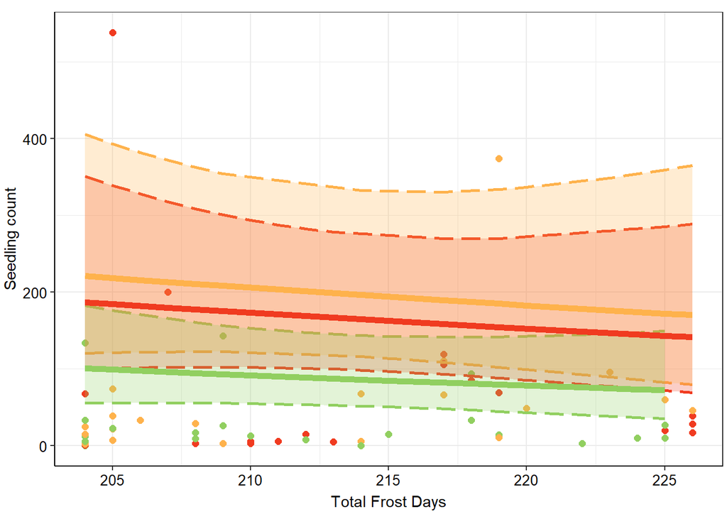

### Figure without raw data

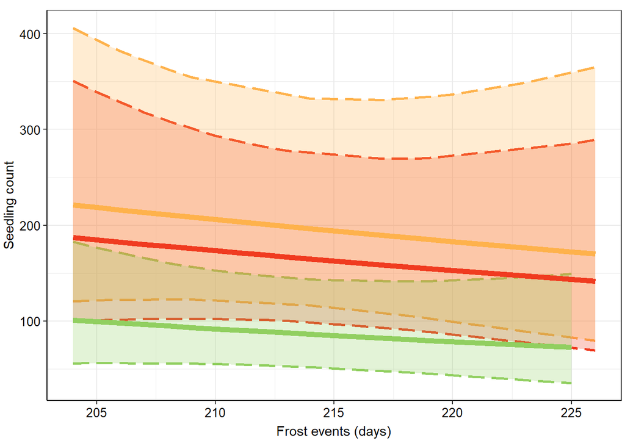

## Model: Snow & fire

```r
snowfire1 = glm.nb(seedling.ct ~ sum_PAS:fire.type + offset(log(seedling.area)), data = seedling.weather)
```

### Residuals

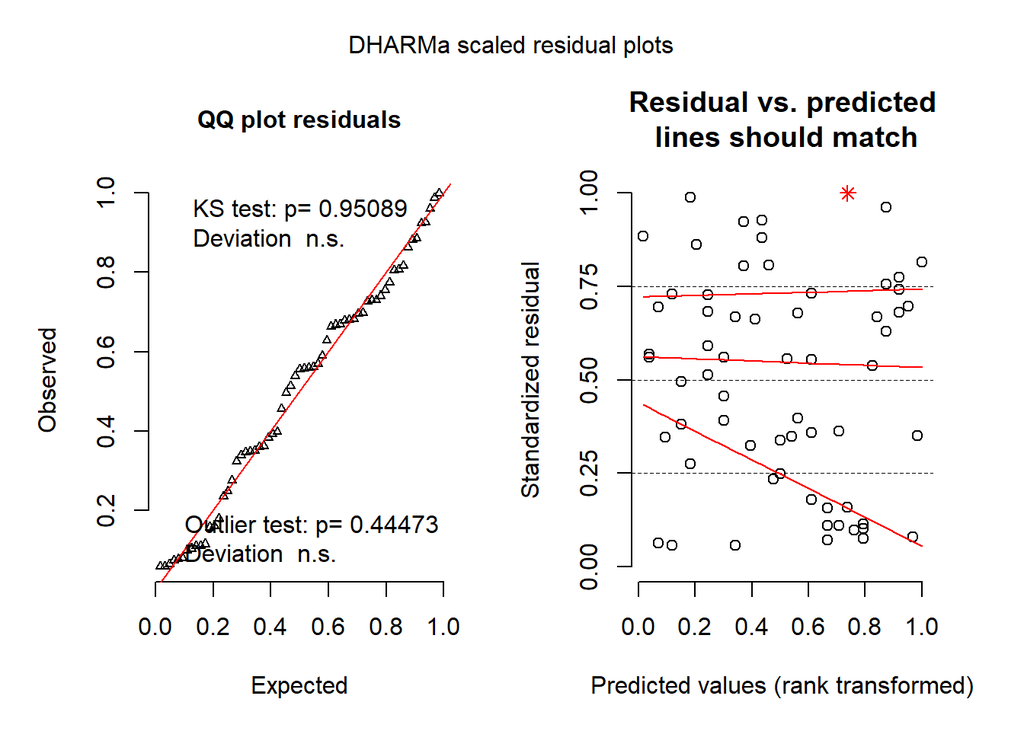

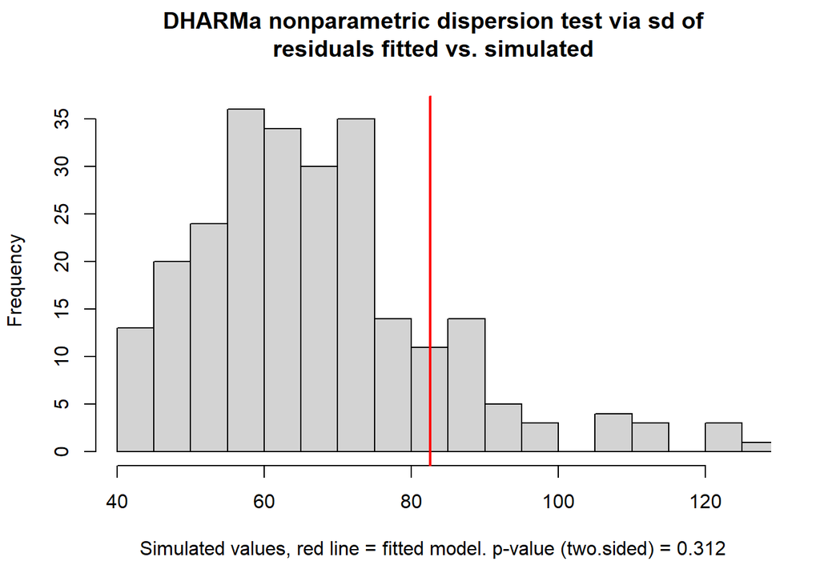

```
##
##  DHARMa nonparametric dispersion test via sd of residuals fitted
##  vs. simulated
##
## data:  simulationOutput
## ratioObsSim = 1.2315, p-value = 0.312
## alternative hypothesis: two.sided
```

```r
testDispersion(snowfire1.res)
```

### Summary

```r
summary(snowfire1)
```

```
##
## Call:
## glm.nb(formula = seedling.ct ~ sum_PAS:fire.type + offset(log(seedling.area)),
##     data = seedling.weather, init.theta = 0.702587106, link = log)
##
## Deviance Residuals:
##     Min       1Q   Median       3Q      Max
## -2.3182  -1.0757  -0.3543   0.1608   2.6072
##
## Coefficients:
##                           Estimate Std. Error z value Pr(>|z|)
## (Intercept)               13.06764    5.40986   2.416  0.01571 *
## sum_PAS:fire.typecrown    -0.07274    0.02907  -2.502  0.01236 *
## sum_PAS:fire.typesev.surf -0.07286    0.02893  -2.519  0.01178 *
## sum_PAS:fire.typesurface  -0.07688    0.02882  -2.668  0.00763 **
## ---
## Signif. codes:  0 '***' 0.001 '**' 0.01 '*' 0.05 '.' 0.1 ' ' 1
##
## (Dispersion parameter for Negative Binomial(0.7026) family taken to be 1)
##
##     Null deviance: 87.394  on 62  degrees of freedom
## Residual deviance: 74.853  on 59  degrees of freedom
## AIC: 609.82
##
## Number of Fisher Scoring iterations: 1
##
##
##               Theta:  0.703
##           Std. Err.:  0.115
##
##  2 x log-likelihood:  -599.823
```

### Estimates

```r
( snowfire1.est = cbind(Estimate = coef(snowfire1), confint(snowfire1)))
```

```
##                              Estimate      2.5 %      97.5 %
## (Intercept)               13.06764330  2.7046756 22.94649991
## sum_PAS:fire.typecrown    -0.07274022 -0.1256859 -0.01670516
## sum_PAS:fire.typesev.surf -0.07285672 -0.1251136 -0.01751634
## sum_PAS:fire.typesurface  -0.07688247 -0.1295277 -0.02129044
```

```r
( exp(snowfire1.est))
```

```
##                               Estimate      2.5 %       97.5 %
## (Intercept)               4.733751e+05 14.9494666 9.237156e+09
## sum_PAS:fire.typecrown    9.298424e-01  0.8818918 9.834336e-01
## sum_PAS:fire.typesev.surf 9.297340e-01  0.8823966 9.826362e-01
## sum_PAS:fire.typesurface  9.259987e-01  0.8785103 9.789346e-01
```

```r
snow_estimate=exp(coef(snowfire1))
snow_lcl_ucl=exp(confint(snowfire1))
snow_p_value=summary(snowfire1)$coefficients[,4]
```

```r
preddat.snowfire1 = data.frame(sum_PAS = seedling.weather$sum_PAS, fire.type = factor(seedling.weather$fire.type), seedling.area = 100)

head(preddat.snowfire1)
```

```
##   sum_PAS fire.type seedling.area
## 1     184  sev.surf           100
## 2     192  sev.surf           100
## 3     194   surface           100
## 4     190  sev.surf           100
## 5     187     crown           100
## 6     194   surface           100
```

```r
predsnowfire1 = predict(snowfire1, newdata = preddat.snowfire1, se.fit = TRUE)

ULsnowfire1 = with(predsnowfire1, fit + 1.96*se.fit)
LLsnowfire1 = with(predsnowfire1, fit - 1.96*se.fit)

seedling.weather = mutate(seedling.weather, predsnowfire1 = exp(predsnowfire1$fit),
               ULsnowfire1 = exp(ULsnowfire1),
               LLsnowfire1 = exp(LLsnowfire1),
               seedling.area = 100)
```

### Figure with raw data

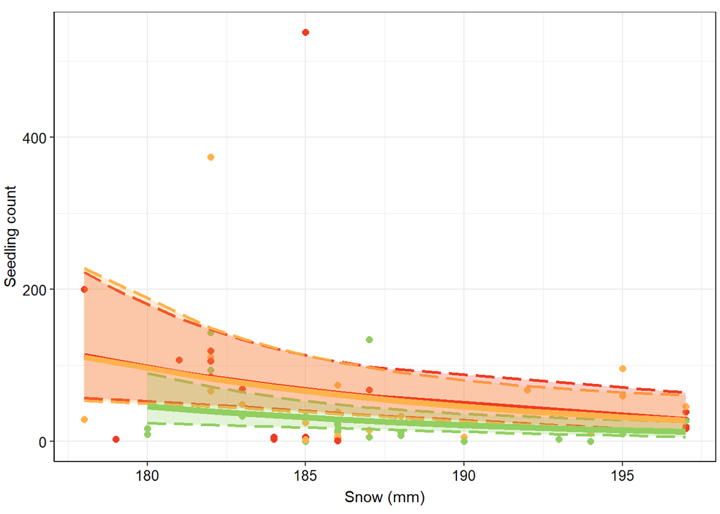

### Figure without raw data

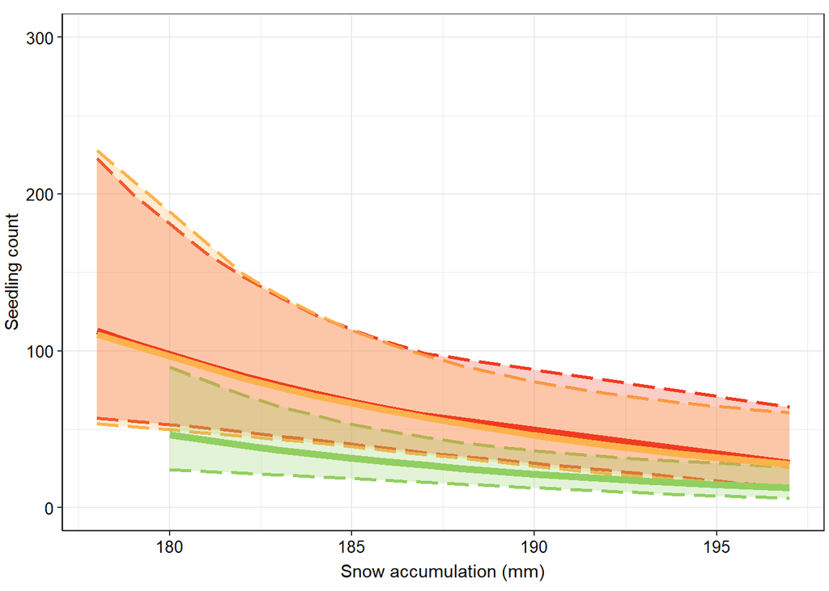

## CMD Model

```r
CMDfire1 = glm.nb(seedling.ct ~ sum_CMD:fire.type + offset(log(seedling.area)), data = seedling.weather)
```

### Residuals

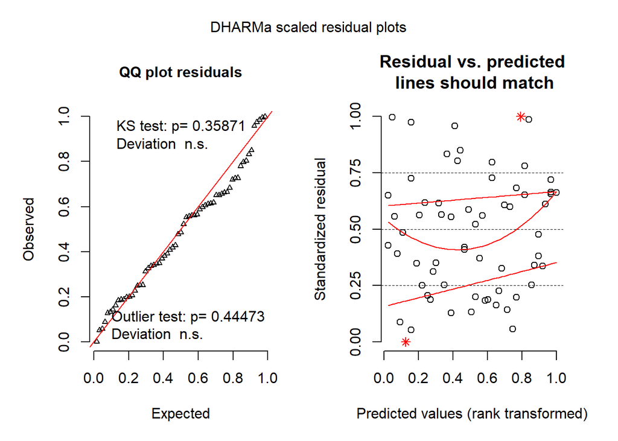

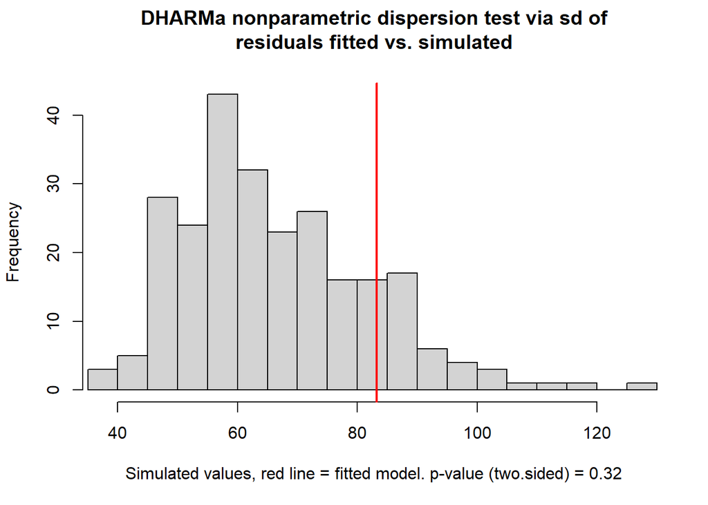

```
##
##  DHARMa nonparametric dispersion test via sd of residuals fitted
##  vs. simulated
##
## data:  simulationOutput
## ratioObsSim = 1.2543, p-value = 0.32
## alternative hypothesis: two.sided
```

```r
testDispersion(CMDfire1.res)
```

### Summary

```r
summary(CMDfire1)
```

```
##
## Call:
## glm.nb(formula = seedling.ct ~ sum_CMD:fire.type + offset(log(seedling.area)),
##     data = seedling.weather, init.theta = 0.6659619508, link = log)
##
## Deviance Residuals:
##      Min        1Q    Median        3Q       Max
## -2.24842  -1.16881  -0.43699   0.01479   2.56909
##
## Coefficients:
##                            Estimate Std. Error z value Pr(>|z|)
## (Intercept)                4.378454   3.347131   1.308   0.1908
## sum_CMD:fire.typecrown    -0.013327   0.009360  -1.424   0.1545
## sum_CMD:fire.typesev.surf -0.014406   0.009509  -1.515   0.1298
## sum_CMD:fire.typesurface  -0.015560   0.009361  -1.662   0.0965 .
## ---
## Signif. codes:  0 '***' 0.001 '**' 0.01 '*' 0.05 '.' 0.1 ' ' 1
##
## (Dispersion parameter for Negative Binomial(0.666) family taken to be 1)
##
##     Null deviance: 83.152  on 62  degrees of freedom
## Residual deviance: 75.277  on 59  degrees of freedom
## AIC: 613.95
##
## Number of Fisher Scoring iterations: 1
##
##
##               Theta:  0.666
##           Std. Err.:  0.108
##
##  2 x log-likelihood:  -603.953
```

### Estimates

```r
( CMDfire1.est = cbind(Estimate = coef(CMDfire1), confint(CMDfire1)))
```

```
##                              Estimate       2.5 %       97.5 %
## (Intercept)                4.37845373 -1.84274727 10.643040700
## sum_CMD:fire.typecrown    -0.01332738 -0.03063897  0.004178586
## sum_CMD:fire.typesev.surf -0.01440646 -0.03242527  0.003707262
## sum_CMD:fire.typesurface  -0.01556042 -0.03272425  0.001713166
```

```r
( exp(CMDfire1.est))
```

```
##                             Estimate     2.5 %       97.5 %
## (Intercept)               79.7146779 0.1583817 41899.983007
## sum_CMD:fire.typecrown     0.9867610 0.9698256     1.004187
## sum_CMD:fire.typesev.surf  0.9856968 0.9680948     1.003714
## sum_CMD:fire.typesurface   0.9845600 0.9678054     1.001715
```

```r
cmd_estimate=exp(coef(CMDfire1))
cmd_lcl_ucl=exp(confint(CMDfire1))
cmd_p_value=summary(CMDfire1)$coefficients[,4]
```

```r
sum_df=data.frame(frost_estimate, frost_lcl_ucl, frost_p_value, snow_estimate, snow_lcl_ucl, snow_p_value, cmd_estimate, cmd_lcl_ucl, cmd_p_value)
sum_df
```

```
##                                frost_estimate      X2.5..      X97.5..
## (Intercept)                        24.9879510 0.000336562 1.363864e+06
## frost.events:fire.typecrown         0.9873744 0.937977404 1.041407e+00
## frost.events:fire.typesev.surf      0.9881850 0.939525731 1.041173e+00
## frost.events:fire.typesurface       0.9843898 0.935173998 1.038112e+00
##                                frost_p_value snow_estimate   X2.5...1
## (Intercept)                        0.4541993  4.733751e+05 14.9494666
## frost.events:fire.typecrown        0.5277679  9.298424e-01  0.8818918
## frost.events:fire.typesev.surf     0.5573190  9.297340e-01  0.8823966
## frost.events:fire.typesurface      0.4372223  9.259987e-01  0.8785103
##                                   X97.5...1 snow_p_value cmd_estimate
## (Intercept)                    9.237156e+09  0.015712622   79.7146779
## frost.events:fire.typecrown    9.834336e-01  0.012355423    0.9867610
## frost.events:fire.typesev.surf 9.826362e-01  0.011775969    0.9856968
## frost.events:fire.typesurface  9.789346e-01  0.007633565    0.9845600
##                                 X2.5...2    X97.5...2 cmd_p_value
## (Intercept)                    0.1583817 41899.983007  0.19083207
## frost.events:fire.typecrown    0.9698256     1.004187  0.15448293
## frost.events:fire.typesev.surf 0.9680948     1.003714  0.12977965
## frost.events:fire.typesurface  0.9678054     1.001715  0.09647649
```

```r
write.csv(sum_df, '../output/2019-02-06_climate_fire_summary.csv', row.names = F)
```

### Predict CMD Data

```r
preddat.cmdfire1 = data.frame(sum_CMD = seedling.weather$sum_CMD, fire.type = factor(seedling.weather$fire.type), seedling.area = 100)

head(preddat.cmdfire1)
```

```
##   sum_CMD fire.type seedling.area
## 1     379  sev.surf           100
## 2     365  sev.surf           100
## 3     365   surface           100
## 4     366  sev.surf           100
## 5     373     crown           100
## 6     364   surface           100
```

```r
predcmdfire1 = predict(CMDfire1, newdata = preddat.cmdfire1, se.fit = TRUE)

ULcmdfire1 = with(predcmdfire1, fit + 1.96*se.fit)
LLcmdfire1 = with(predcmdfire1, fit - 1.96*se.fit)

seedling.weather = mutate(seedling.weather, predcmdfire1 = exp(predcmdfire1$fit),
               ULcmdfire1 = exp(ULcmdfire1),
               LLcmdfire1 = exp(LLcmdfire1),
               seedling.area = 100)
```

### Figure with raw data

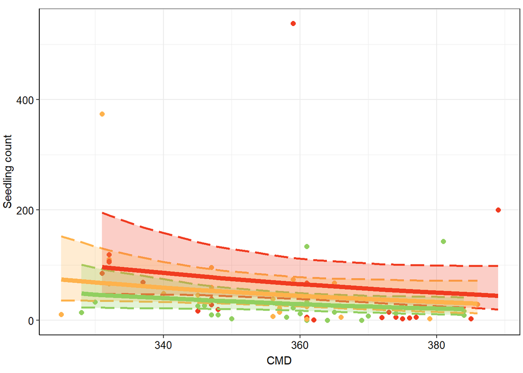

### Figure without raw data

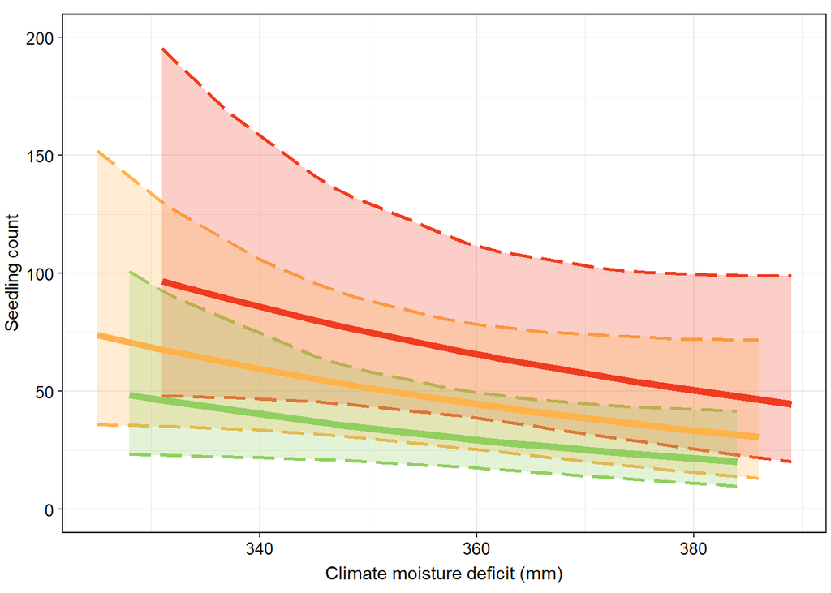

# Remove outliers

Remove prominent outliers (Plots - 27, 34, 40) and rerun analyses

```r
head(seedling.weather)
```

```
##   plot  MPB fire.severity utm_zone  UTM_E   UTM_N Elevation fire.event
## 1    1  low      moderate       10 334151 5904342       937  chelaslie
## 2    2  low      moderate       10 334730 5905754      1039  chelaslie
## 3    3  low           low       10 334790 5905867      1043  chelaslie
## 4    4 high      moderate       10 334297 5905505      1025  chelaslie
## 5    5  low          high       10 334541 5905225       989  chelaslie
## 6    6  low           low       10 333922 5906030      1028  chelaslie
##   fire.year      lat      long sum_PPT  avg_PPT sum_NFFD avg_NFFD sum_PAS
## 1      2014 53.26237 -125.4866     476 39.66667      156 13.00000     184
## 2      2014 53.27523 -125.4787     482 40.16667      151 12.58333     192
## 3      2014 53.27626 -125.4778     482 40.16667      150 12.50000     194
## 4      2014 53.27285 -125.4850     484 40.33333      151 12.58333     190
## 5      2014 53.27042 -125.4812     479 39.91667      153 12.75000     187
## 6      2014 53.27745 -125.4909     487 40.58333      151 12.58333     194
##    avg_PAS sum_CMD  avg_CMD frost.events aspect slope aspect_rad
```

[output cut: 48 more lines]

```r
seed_clim_out = subset(seedling.weather, plot != 27 & plot != 34 & plot != 40)

datatable(seed_clim_out)
```

|  | plot | MPB | fire.severity | utm_zone | UTM_E | UTM_N | Elevation | fire.event | fire.year | lat | long | sum_PPT | avg_PPT | sum_NFFD | avg_NFFD | sum_PAS | avg_PAS | sum_CMD | avg_CMD | frost.events | aspect | slope | aspect_rad | foldaspect_rad | slope_rad | lat_degrees | lat_rad | heatload | seedling.ct | … |
| --- | --- | --- | --- | --- | --- | --- | --- | --- | --- | --- | --- | --- | --- | --- | --- | --- | --- | --- | --- | --- | --- | --- | --- | --- | --- | --- | --- | --- | --- | --- |
| 1 | 1 | low | moderate | 10 | 334151 | 5904342 | 937 | chelaslie | 2014 | 53.262365 | -125.48661 | 476 | 39.6666666666667 | 156 | 13 | 184 | 15.3333333333333 | 379 | 31.5833333333333 | 209 | 0 | 5 | 0 | -0.785398163397448 | 0.0872664625997165 | 53 | 0.925024503556995 | 0.780068539333662 | 3 | … |
| 2 | 2 | low | moderate | 10 | 334730 | 5905754 | 1039 | chelaslie | 2014 | 53.275226 | -125.478668 | 482 | 40.1666666666667 | 151 | 12.5833333333333 | 192 | 16 | 365 | 30.4166666666667 | 214 | 155 | 0 | 2.70526034059121 | 1.91986217719376 | 0 | 53 | 0.925024503556995 | 0.825266538706855 | 68 | … |
| 3 | 3 | low | low | 10 | 334790 | 5905867 | 1043 | chelaslie | 2014 | 53.27626 | -125.477829 | 482 | 40.1666666666667 | 150 | 12.5 | 194 | 16.1666666666667 | 365 | 30.4166666666667 | 215 | 165 | 2 | 2.87979326579064 | 2.0943951023932 | 0.0349065850398866 | 53 | 0.925024503556995 | 0.827918189414778 | 15 | … |
| 4 | 4 | high | moderate | 10 | 334297 | 5905505 | 1025 | chelaslie | 2014 | 53.272855 | -125.485023 | 484 | 40.3333333333333 | 151 | 12.5833333333333 | 190 | 15.8333333333333 | 366 | 30.5 | 214 | 168 | 5 | 2.93215314335047 | 2.14675497995303 | 0.0872664625997165 | 53 | 0.925024503556995 | 0.832653214450661 | 6 | … |
| 5 | 5 | low | high | 10 | 334541 | 5905225 | 989 | chelaslie | 2014 | 53.270417 | -125.481224 | 479 | 39.9166666666667 | 153 | 12.75 | 187 | 15.5833333333333 | 373 | 31.0833333333333 | 212 | 227 | 0 | 3.96189740202713 | 3.10668606854991 | 0 | 53 | 0.925024503556995 | 0.825266538706855 | 15 | … |
| 6 | 6 | low | low | 10 | 333922 | 5906030 | 1028 | chelaslie | 2014 | 53.277453 | -125.490921 | 487 | 40.5833333333333 | 151 | 12.5833333333333 | 194 | 16.1666666666667 | 364 | 30.3333333333333 | 214 | 264 | 5 | 4.60766922526503 | 2.46091424531201 | 0.0872664625997165 | 53 | 0.925024503556995 | 0.842420613735048 | 0 | … |
| 7 | 7 | high | high | 10 | 334510 | 5904882 | 960 | chelaslie | 2014 | 53.267327 | -125.481514 | 477 | 39.75 | 155 | 12.9166666666667 | 184 | 15.3333333333333 | 376 | 31.3333333333333 | 210 | 234 | 20 | 4.08407044966673 | 2.9845130209103 | 0.349065850398866 | 53 | 0.925024503556995 | 0.905227875927228 | 4 | … |
| 8 | 8 | moderate | high | 10 | 334391 | 5904692 | 949 | chelaslie | 2014 | 53.265583 | -125.483192 | 477 | 39.75 | 155 | 12.9166666666667 | 184 | 15.3333333333333 | 377 | 31.4166666666667 | 210 | 188 | 2 | 3.28121899374934 | 2.49582083035189 | 0.0349065850398866 | 53 | 0.925024503556995 | 0.832941703791884 | 6 | … |
| 9 | 9 | low | high | 10 | 335119 | 5904973 | 985 | chelaslie | 2014 | 53.268334 | -125.472435 | 476 | 39.6666666666667 | 154 | 12.8333333333333 | 186 | 15.5 | 374 | 31.1666666666667 | 211 | 146 | 2 | 2.54818070791172 | 1.76278254451427 | 0.0349065850398866 | 53 | 0.925024503556995 | 0.822717115179662 | 6 | … |
| 10 | 10 | low | high | 10 | 334978 | 5905205 | 997 | chelaslie | 2014 | 53.270373 | -125.47467 | 477 | 39.75 | 152 | 12.6666666666667 | 186 | 15.5 | 372 | 31 | 213 | 205 | 1 | 3.57792496658838 | 2.79252680319093 | 0.0174532925199433 | 53 | 0.925024503556995 | 0.830365358716716 | 5 | … |

[output cut: 50 more lines]

## Analayses: Postfire Climate & Fire Severity

### Frost Model (outliers removed)

```r
ofrostfire1 = glm.nb(seedling.ct ~ frost.events:fire.type + offset(log(seedling.area)), data = seed_clim_out)
```

#### Residuals

In the plot below we are looking for the points in the QQ plot to fall along the RED lines. In the Residuals vs.predicted plot were are looking for the lines to be relatively horizontal. All looks good.

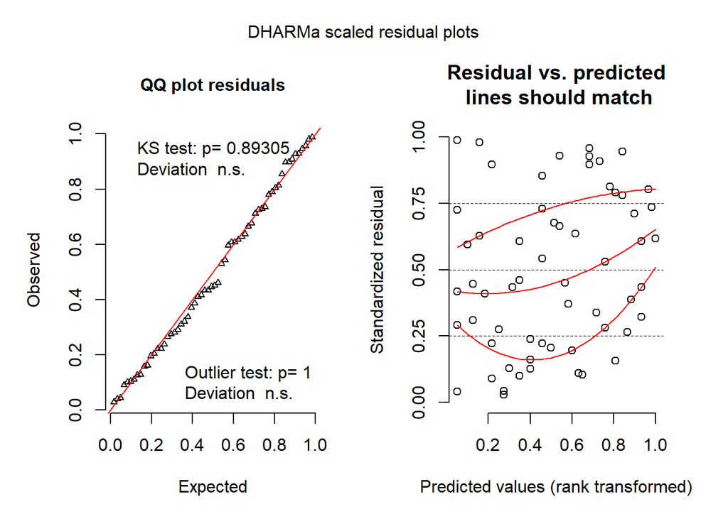

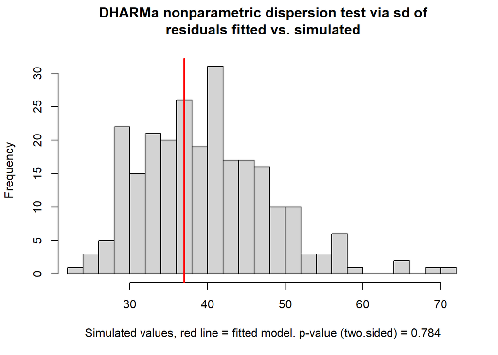

```
##
##  DHARMa nonparametric dispersion test via sd of residuals fitted
##  vs. simulated
##
## data:  simulationOutput
## ratioObsSim = 0.93102, p-value = 0.784
## alternative hypothesis: two.sided
```

```r
testDispersion(ofrostfire1.res)
```

#### Summary

```r
summary(ofrostfire1)
```

```
##
## Call:
## glm.nb(formula = seedling.ct ~ frost.events:fire.type + offset(log(seedling.area)),
##     data = seed_clim_out, init.theta = 0.8117805378, link = log)
##
## Deviance Residuals:
##     Min       1Q   Median       3Q      Max
## -2.4370  -1.0765  -0.4919   0.1992   2.1005
##
## Coefficients:
##                                Estimate Std. Error z value Pr(>|z|)
## (Intercept)                    -6.02277    4.19352  -1.436    0.151
## frost.events:fire.typecrown     0.02329    0.01955   1.191    0.234
## frost.events:fire.typesev.surf  0.02387    0.01978   1.207    0.227
## frost.events:fire.typesurface   0.02262    0.01974   1.146    0.252
##
## (Dispersion parameter for Negative Binomial(0.8118) family taken to be 1)
##
##     Null deviance: 72.857  on 59  degrees of freedom
## Residual deviance: 70.572  on 56  degrees of freedom
## AIC: 553.97
##
## Number of Fisher Scoring iterations: 1
##
##
##               Theta:  0.812
##           Std. Err.:  0.141
##
##  2 x log-likelihood:  -543.971
```

#### Estimates

```r
( ofrostfire1.est = cbind(Estimate = coef(ofrostfire1), confint(ofrostfire1)))
```

```
##                                   Estimate        2.5 %     97.5 %
## (Intercept)                    -6.02276794 -15.22052697 3.10363828
## frost.events:fire.typecrown     0.02328960  -0.01885032 0.06603726
## frost.events:fire.typesev.surf  0.02387112  -0.01861958 0.06716539
## frost.events:fire.typesurface   0.02262140  -0.02067835 0.06660615
```

```r
( exp(ofrostfire1.est))
```

```
##                                   Estimate        2.5 %    97.5 %
## (Intercept)                    0.002422954 2.453630e-07 22.278861
## frost.events:fire.typecrown    1.023562924 9.813262e-01  1.068267
## frost.events:fire.typesev.surf 1.024158320 9.815527e-01  1.069472
## frost.events:fire.typesurface  1.022879202 9.795340e-01  1.068874
```

```r
ofrost_estimate=exp(coef(ofrostfire1))
ofrost_lcl_ucl=exp(confint(ofrostfire1))
ofrost_p_value=summary(ofrostfire1)$coefficients[,4]
```

#### Predict

```r
preddat.ofrostfire1 = data.frame(frost.events = seed_clim_out$frost.events, fire.type = factor(seed_clim_out$fire.type), seedling.area = 100)

head(preddat.ofrostfire1)
```

```
##   frost.events fire.type seedling.area
## 1          209  sev.surf           100
## 2          214  sev.surf           100
## 3          215   surface           100
## 4          214  sev.surf           100
## 5          212     crown           100
## 6          214   surface           100
```

```r
predofrostfire1 = predict(ofrostfire1, newdata = preddat.ofrostfire1, se.fit = TRUE)

ULofrostfire1 = with(predofrostfire1, fit + 1.96*se.fit)
LLofrostfire1 = with(predofrostfire1, fit - 1.96*se.fit)

seed_clim_out = mutate(seed_clim_out, predofrostfire1 = exp(predofrostfire1$fit),
               ULofrostfire1 = exp(ULofrostfire1),
               LLofrostfire1 = exp(LLofrostfire1),
               seedling.area = 100)
```

#### Figure with raw data

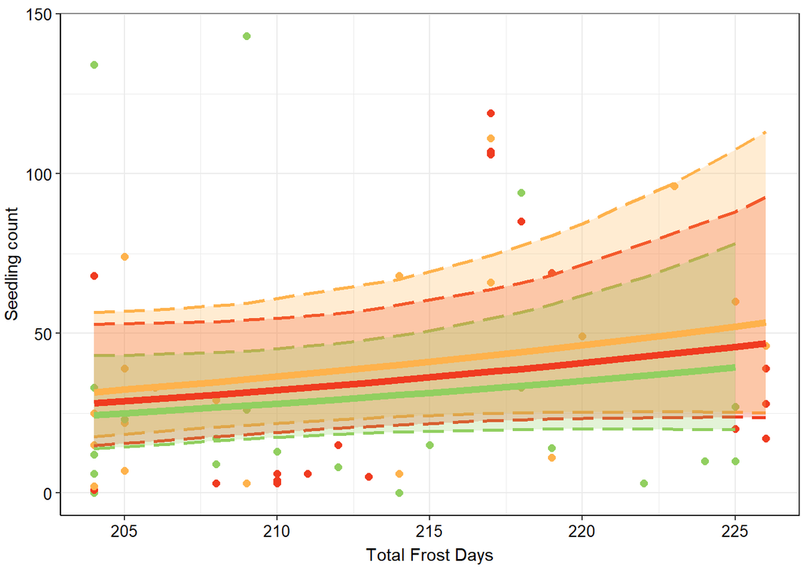

#### Figure without raw data

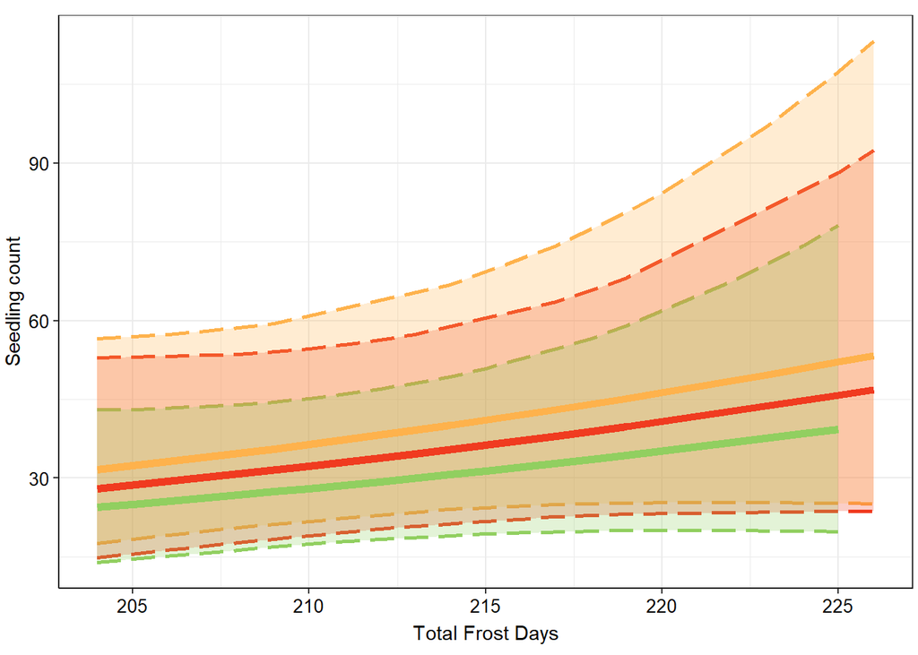

## Snow Model (outliers removed)

```r
osnowfire1 = glm.nb(seedling.ct ~ sum_PAS:fire.type + offset(log(seedling.area)), data = seed_clim_out)
```

### Residuals

In the plot below we are looking for the points in the QQ plot to fall along the RED lines. In the Residuals vs.predicted plot were are looking for the lines to be relatively horizontal. All looks good.

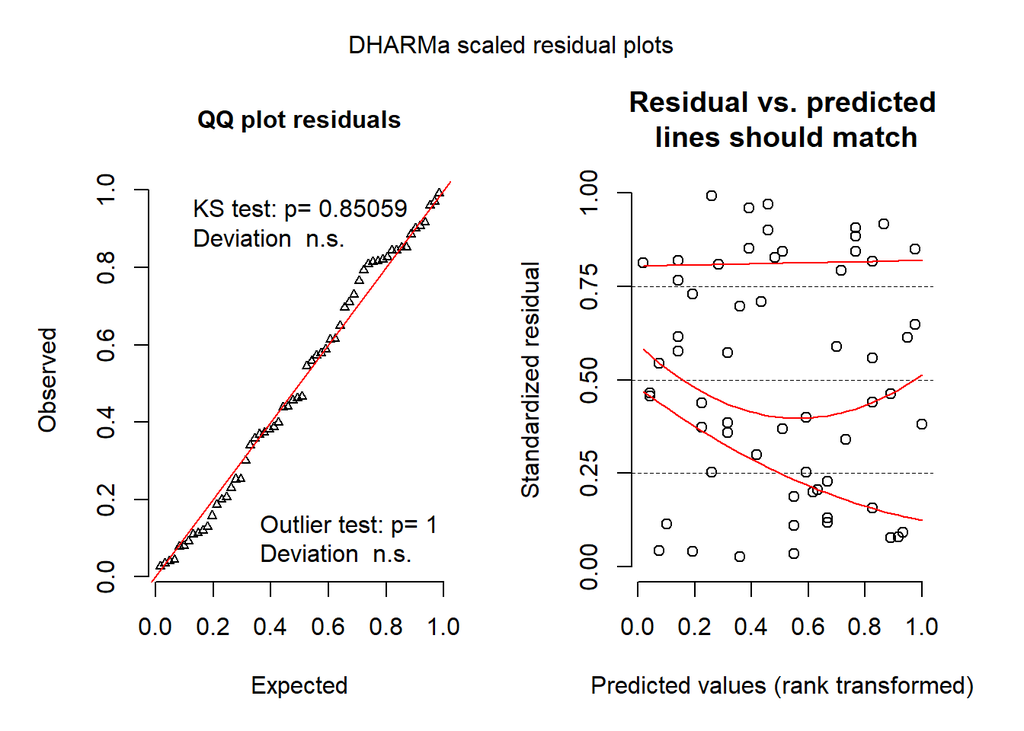

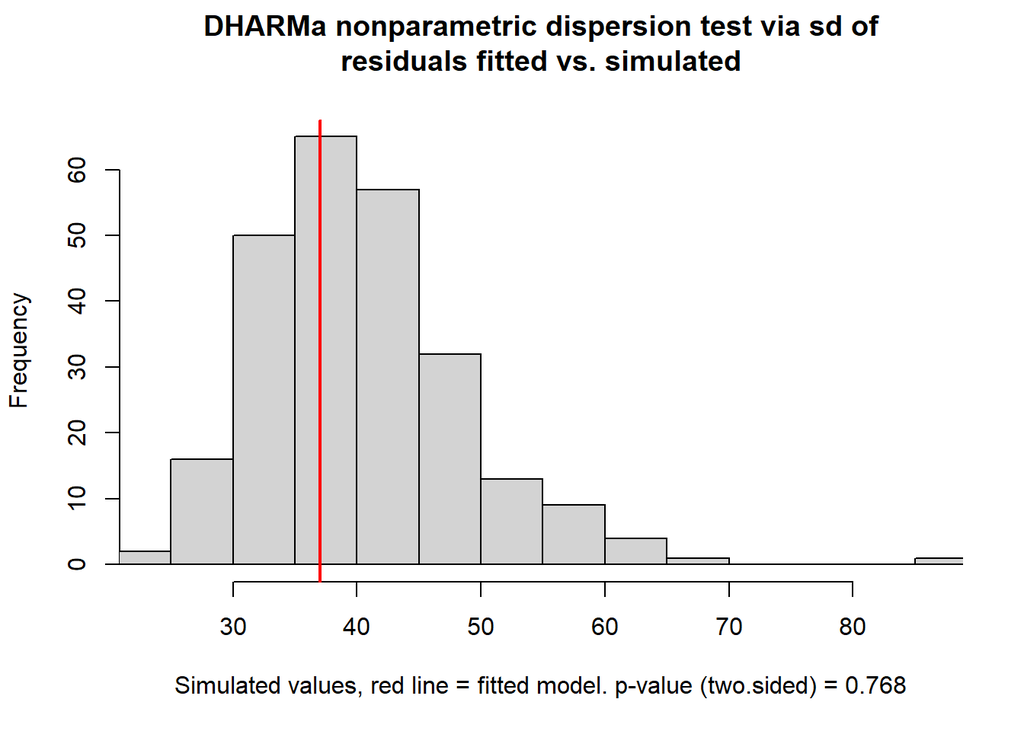

```
##
##  DHARMa nonparametric dispersion test via sd of residuals fitted
##  vs. simulated
##
## data:  simulationOutput
## ratioObsSim = 0.91784, p-value = 0.768
## alternative hypothesis: two.sided
```

```r
testDispersion(osnowfire1.res)
```

#### Summary

```r
summary(osnowfire1)
```

```
##
## Call:
## glm.nb(formula = seedling.ct ~ sum_PAS:fire.type + offset(log(seedling.area)),
##     data = seed_clim_out, init.theta = 0.8333535009, link = log)
##
## Deviance Residuals:
##     Min       1Q   Median       3Q      Max
## -2.4508  -1.2462  -0.4966   0.4854   1.9586
##
## Coefficients:
##                           Estimate Std. Error z value Pr(>|z|)
## (Intercept)                7.57189    5.14309   1.472   0.1410
## sum_PAS:fire.typecrown    -0.04613    0.02757  -1.673   0.0943 .
## sum_PAS:fire.typesev.surf -0.04496    0.02746  -1.637   0.1015
## sum_PAS:fire.typesurface  -0.04748    0.02739  -1.733   0.0831 .
## ---
## Signif. codes:  0 '***' 0.001 '**' 0.01 '*' 0.05 '.' 0.1 ' ' 1
##
## (Dispersion parameter for Negative Binomial(0.8334) family taken to be 1)
##
##     Null deviance: 74.599  on 59  degrees of freedom
## Residual deviance: 70.420  on 56  degrees of freedom
## AIC: 552.16
##
## Number of Fisher Scoring iterations: 1
##
##
##               Theta:  0.833
##           Std. Err.:  0.145
##
##  2 x log-likelihood:  -542.160
```

#### Estimates

```r
( osnowfire1.est = cbind(Estimate = coef(osnowfire1), confint(osnowfire1)))
```

```
##                              Estimate       2.5 %       97.5 %
## (Intercept)                7.57188844 -2.12298932 16.862963240
## sum_PAS:fire.typecrown    -0.04612767 -0.09572241  0.006148307
## sum_PAS:fire.typesev.surf -0.04496232 -0.09390876  0.006515166
## sum_PAS:fire.typesurface  -0.04747715 -0.09718715  0.004689114
```

```r
( exp(osnowfire1.est))
```

```
##                               Estimate     2.5 %       97.5 %
## (Intercept)               1942.8056970 0.1196734 2.106163e+07
## sum_PAS:fire.typecrown       0.9549200 0.9087162 1.006167e+00
## sum_PAS:fire.typesev.surf    0.9560335 0.9103658 1.006536e+00
## sum_PAS:fire.typesurface     0.9536323 0.9073862 1.004700e+00
```

```r
osnow_estimate=exp(coef(osnowfire1))
osnow_lcl_ucl=exp(confint(osnowfire1))
osnow_p_value=summary(osnowfire1)$coefficients[,4]
```

#### Predict

```r
preddat.osnowfire1 = data.frame(sum_PAS = seed_clim_out$sum_PAS, fire.type = factor(seed_clim_out$fire.type), seedling.area = 100)

head(preddat.osnowfire1)
```

```
##   sum_PAS fire.type seedling.area
## 1     184  sev.surf           100
## 2     192  sev.surf           100
## 3     194   surface           100
## 4     190  sev.surf           100
## 5     187     crown           100
## 6     194   surface           100
```

```r
predosnowfire1 = predict(osnowfire1, newdata = preddat.osnowfire1, se.fit = TRUE)

ULosnowfire1 = with(predosnowfire1, fit + 1.96*se.fit)
LLosnowfire1 = with(predosnowfire1, fit - 1.96*se.fit)

seed_clim_out = mutate(seed_clim_out, predosnowfire1 = exp(predosnowfire1$fit),
               ULosnowfire1 = exp(ULosnowfire1),
               LLosnowfire1 = exp(LLosnowfire1),
               seedling.area = 100)
```

#### Figure with raw data

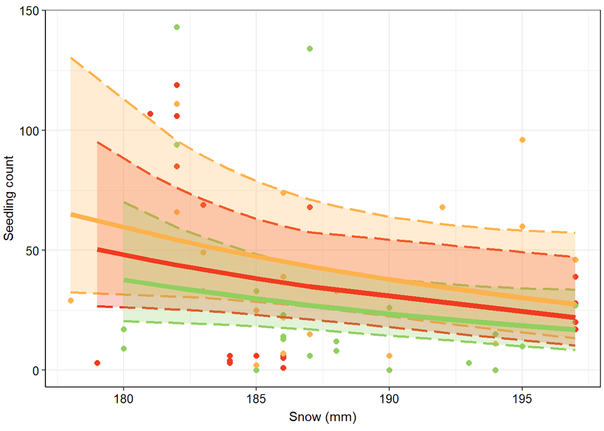

#### Figure without raw data

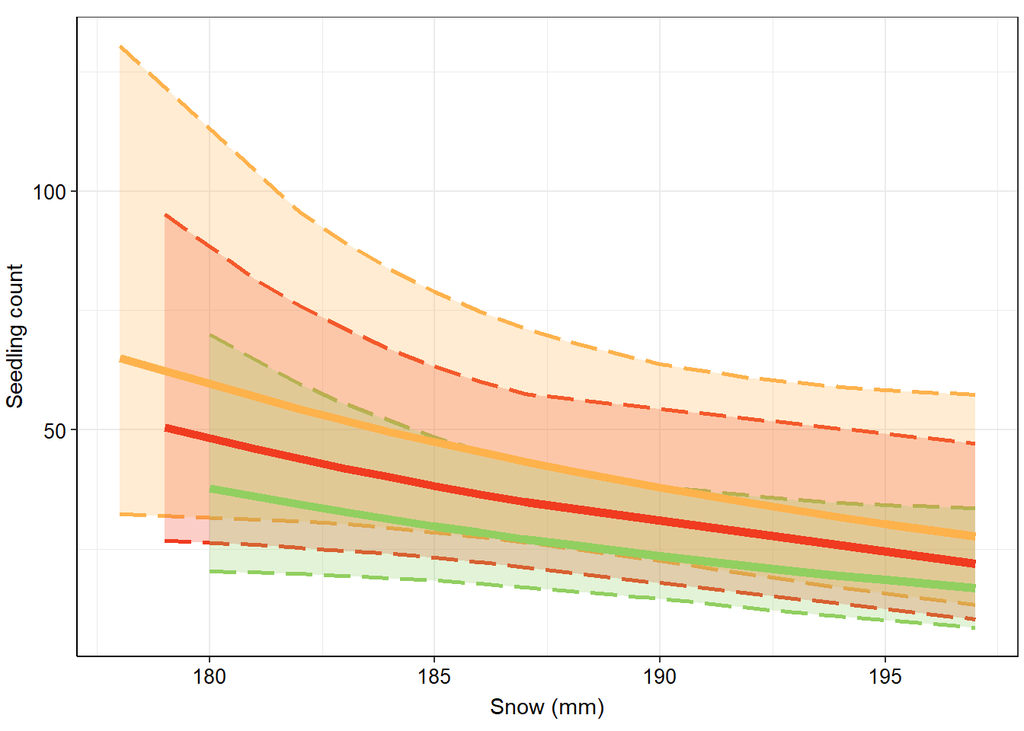

## CMD Model (outliers removed)

```r
oCMDfire1 = glm.nb(seedling.ct ~ sum_CMD:fire.type + offset(log(seedling.area)), data = seed_clim_out)
```

### Residuals

In the plot below we are looking for the points in the QQ plot to fall along the RED lines. In the Residuals vs.predicted plot were are looking for the lines to be relatively horizontal. All looks good.

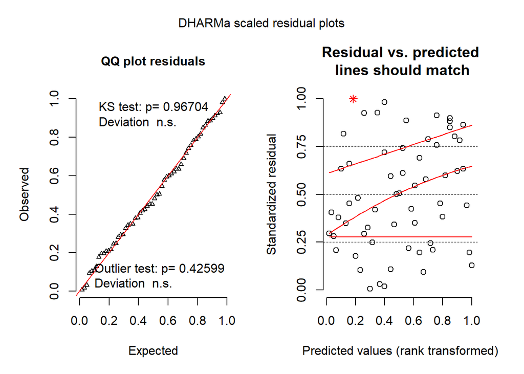

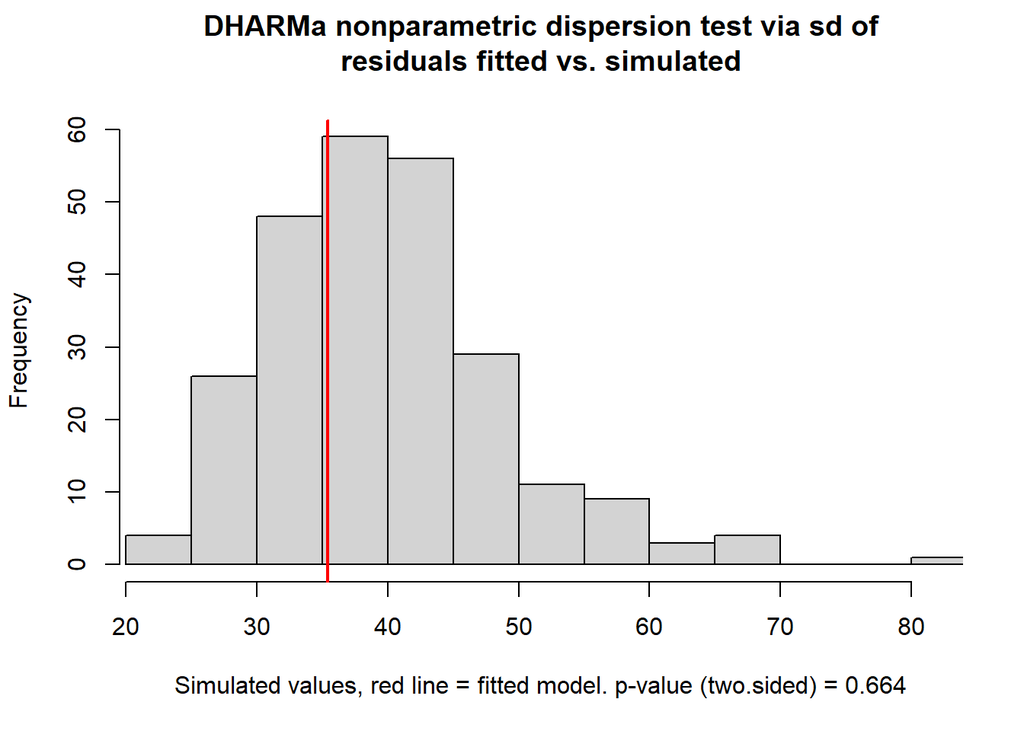

```
##
##  DHARMa nonparametric dispersion test via sd of residuals fitted
##  vs. simulated
##
## data:  simulationOutput
## ratioObsSim = 0.88791, p-value = 0.664
## alternative hypothesis: two.sided
```

```r
testDispersion(oCMDfire1.res)
```

#### Summary

```r
summary(oCMDfire1)
```

```
##
## Call:
## glm.nb(formula = seedling.ct ~ sum_CMD:fire.type + offset(log(seedling.area)),
##     data = seed_clim_out, init.theta = 0.9093029377, link = log)
##
## Deviance Residuals:
##     Min       1Q   Median       3Q      Max
## -2.5373  -1.0177  -0.4418   0.2002   2.9576
##
## Coefficients:
##                            Estimate Std. Error z value Pr(>|z|)
## (Intercept)                8.522808   3.023364   2.819  0.00482 **
## sum_CMD:fire.typecrown    -0.027790   0.008503  -3.268  0.00108 **
## sum_CMD:fire.typesev.surf -0.026850   0.008564  -3.135  0.00172 **
## sum_CMD:fire.typesurface  -0.026904   0.008456  -3.182  0.00146 **
## ---
## Signif. codes:  0 '***' 0.001 '**' 0.01 '*' 0.05 '.' 0.1 ' ' 1
##
## (Dispersion parameter for Negative Binomial(0.9093) family taken to be 1)
##
##     Null deviance: 80.683  on 59  degrees of freedom
## Residual deviance: 70.040  on 56  degrees of freedom
## AIC: 546.32
##
## Number of Fisher Scoring iterations: 1
##
##
##               Theta:  0.909
##           Std. Err.:  0.161
##
##  2 x log-likelihood:  -536.320
```

#### Estimates

```r
( oCMDfire1.est = cbind(Estimate = coef(oCMDfire1), confint(oCMDfire1)))
```

```
##                              Estimate       2.5 %       97.5 %
## (Intercept)                8.52280770  2.48637793 14.605182453
## sum_CMD:fire.typecrown    -0.02778972 -0.04525243 -0.010239806
## sum_CMD:fire.typesev.surf -0.02684999 -0.04396501 -0.009691786
## sum_CMD:fire.typesurface  -0.02690431 -0.04344564 -0.010306154
```

```r
( exp(oCMDfire1.est))
```

```
##                               Estimate      2.5 %       97.5 %
## (Intercept)               5028.1514960 12.0176683 2.202674e+06
## sum_CMD:fire.typecrown       0.9725929  0.9557562 9.898124e-01
## sum_CMD:fire.typesev.surf    0.9735073  0.9569874 9.903550e-01
## sum_CMD:fire.typesurface     0.9734544  0.9574846 9.897468e-01
```

```r
summary(oCMDfire1)$coefficients[,4]
```

```
##               (Intercept)    sum_CMD:fire.typecrown
##               0.004817630               0.001082383
## sum_CMD:fire.typesev.surf  sum_CMD:fire.typesurface
##               0.001718133               0.001463794
```

```r
ocmd_estimate=exp(coef(oCMDfire1))
ocmd_lcl_ucl=exp(confint(oCMDfire1))
ocmd_p_value=summary(oCMDfire1)$coefficients[,4]
```

```r
out_df=data.frame(ofrost_estimate, ofrost_lcl_ucl, ofrost_p_value, osnow_estimate, osnow_lcl_ucl, osnow_p_value, ocmd_estimate, ocmd_lcl_ucl, ocmd_p_value)
out_df
```

```
##                                ofrost_estimate       X2.5..   X97.5..
## (Intercept)                        0.002422954 2.453630e-07 22.278861
## frost.events:fire.typecrown        1.023562924 9.813262e-01  1.068267
## frost.events:fire.typesev.surf     1.024158320 9.815527e-01  1.069472
## frost.events:fire.typesurface      1.022879202 9.795340e-01  1.068874
##                                ofrost_p_value osnow_estimate  X2.5...1
## (Intercept)                         0.1509429   1942.8056970 0.1196734
## frost.events:fire.typecrown         0.2336555      0.9549200 0.9087162
## frost.events:fire.typesev.surf      0.2274957      0.9560335 0.9103658
## frost.events:fire.typesurface       0.2518335      0.9536323 0.9073862
##                                   X97.5...1 osnow_p_value ocmd_estimate
## (Intercept)                    2.106163e+07    0.14095442  5028.1514960
## frost.events:fire.typecrown    1.006167e+00    0.09432080     0.9725929
## frost.events:fire.typesev.surf 1.006536e+00    0.10153410     0.9735073
## frost.events:fire.typesurface  1.004700e+00    0.08305502     0.9734544
##                                  X2.5...2    X97.5...2 ocmd_p_value
## (Intercept)                    12.0176683 2.202674e+06  0.004817630
## frost.events:fire.typecrown     0.9557562 9.898124e-01  0.001082383
## frost.events:fire.typesev.surf  0.9569874 9.903550e-01  0.001718133
## frost.events:fire.typesurface   0.9574846 9.897468e-01  0.001463794
```

```r
write.csv(out_df, '../output/2019-02-06_climate_fire_outliers.csv', row.names = F)
```

#### Predict

```r
preddat.ocmdfire1 = data.frame(sum_CMD = seed_clim_out$sum_CMD, fire.type = factor(seed_clim_out$fire.type), seedling.area = 100)

head(preddat.ocmdfire1)
```

```
##   sum_CMD fire.type seedling.area
## 1     379  sev.surf           100
## 2     365  sev.surf           100
## 3     365   surface           100
## 4     366  sev.surf           100
## 5     373     crown           100
## 6     364   surface           100
```

```r
predocmdfire1 = predict(oCMDfire1, newdata = preddat.ocmdfire1, se.fit = TRUE)

ULocmdfire1 = with(predocmdfire1, fit + 1.96*se.fit)
LLocmdfire1 = with(predocmdfire1, fit - 1.96*se.fit)

seed_clim_out = mutate(seed_clim_out, predocmdfire1 = exp(predocmdfire1$fit),
               ULocmdfire1 = exp(ULocmdfire1),
               LLocmdfire1 = exp(LLocmdfire1),
               seedling.area = 100)
```

#### Figure with raw data

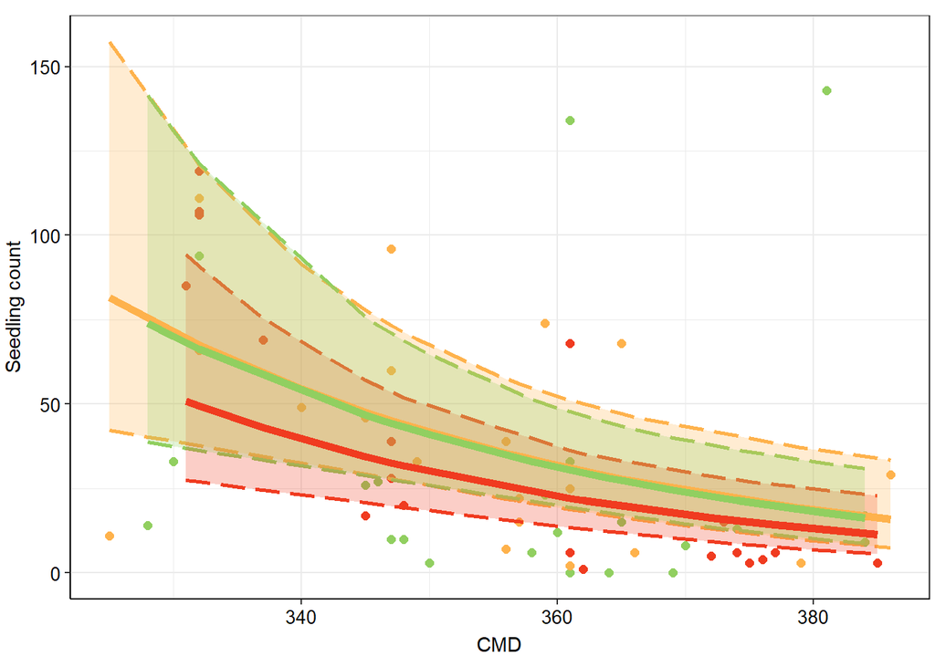

#### Figure without raw data

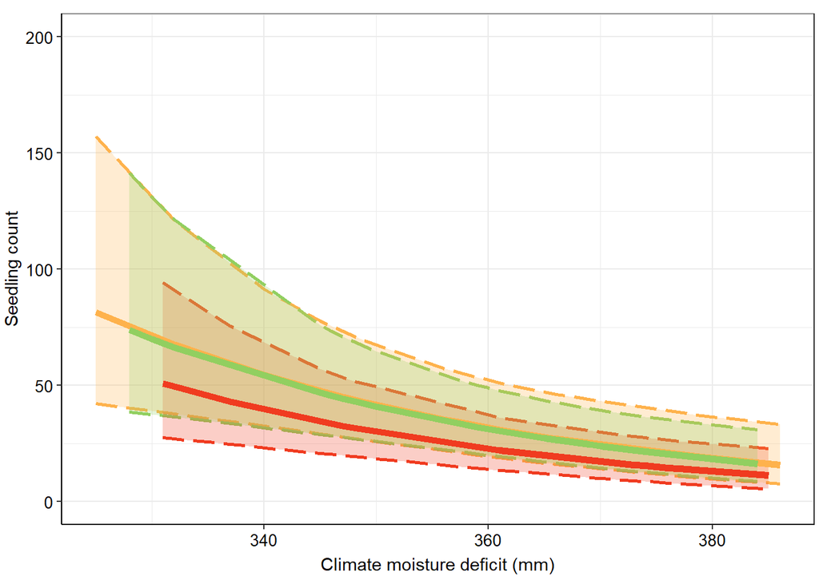

```r
pocmdfire4 = ggplot(data = seed_clim_out, aes(x = sum_CMD, y = seedling.ct, color = factor(fire.type))) +
              geom_line(aes(y=LLocmdfire1, color = factor(fire.type)), linetype = 'longdash', size = 1) +
              geom_line(aes(y=ULocmdfire1, color = factor(fire.type)), linetype='longdash', size = 1) +
              scale_linetype(guide = "none")

pocmdfire5 = pocmdfire4 +
      geom_ribbon(aes(ymin=LLocmdfire1, ymax=ULocmdfire1, fill= fire.type), linetype = 0, alpha=.25, show.legend = FALSE) +
      scale_fill_manual(values=c("#f03b20", "#feb24c", "#91cf60"), guide = FALSE)

pocmdfire6 = pocmdfire5 + geom_line(aes(y = predocmdfire1, color = factor(fire.type)), linetype = 1, size = 2) +
         scale_color_manual(values = c("#f03b20", "#feb24c", "#91cf60"), name="Fire Severity",
                         breaks=c("crown", "sev.surf", "surface"),
                         labels=c("Crown", "Severe surface", "Light surface")) +
    ylab("Seedling count") +
    xlab("Climate moisture deficit (mm)")  +
    ylim(0, 200) +
    theme_bw() +
    theme(legend.position = "none") +
    theme(plot.margin = unit(c(t = 0.3, r = 0.1, b = 0.3, l = 0.1), "cm")) +
    theme(axis.title.x = element_text(size = 11, hjust = 0.5, vjust = -0.1),
        axis.title.y = element_text(size = 11, hjust = 0.5, vjust = 1.1),
        axis.text.x = element_text(size = 10, color = "black"),
        axis.text.y = element_text(size = 10, color = "black"),
        panel.background = element_blank(),
        axis.line = element_line(colour = "black"))

pocmdfire6
```

#### Legend

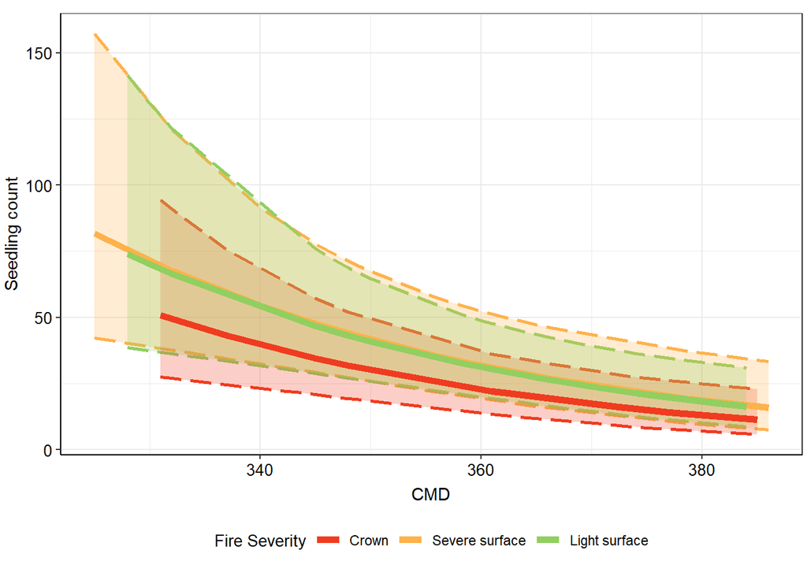

# Figures with and without outliers

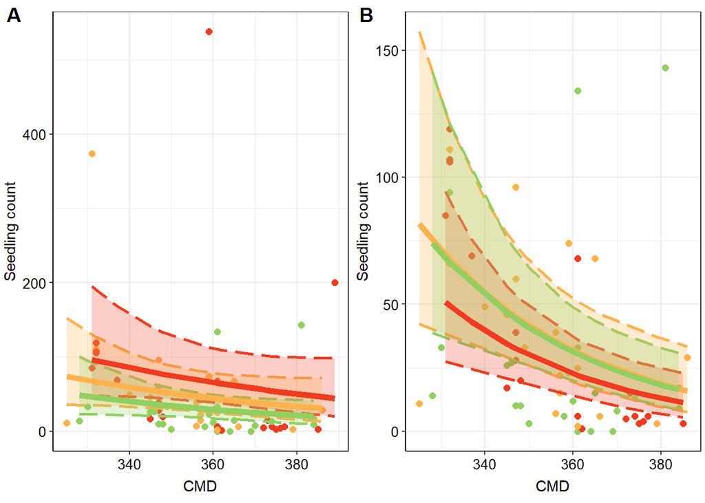

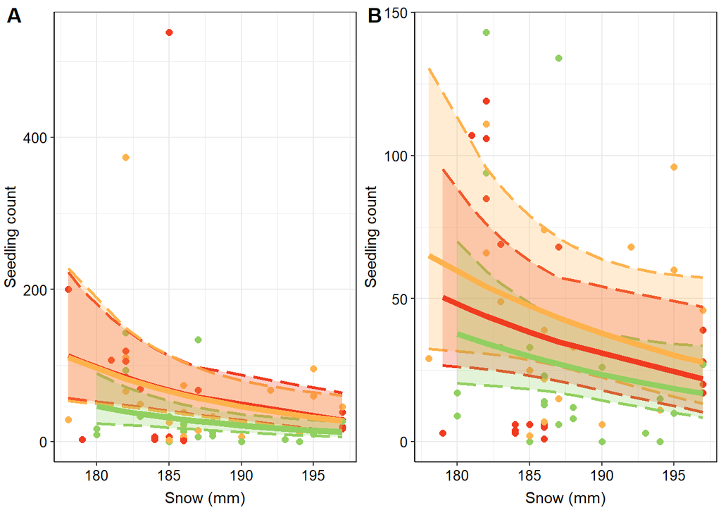

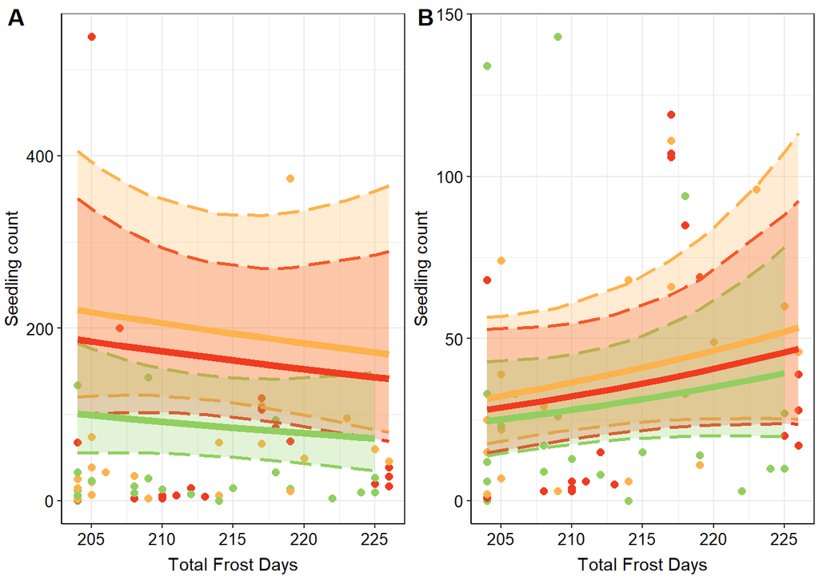

# Manuscript Figure

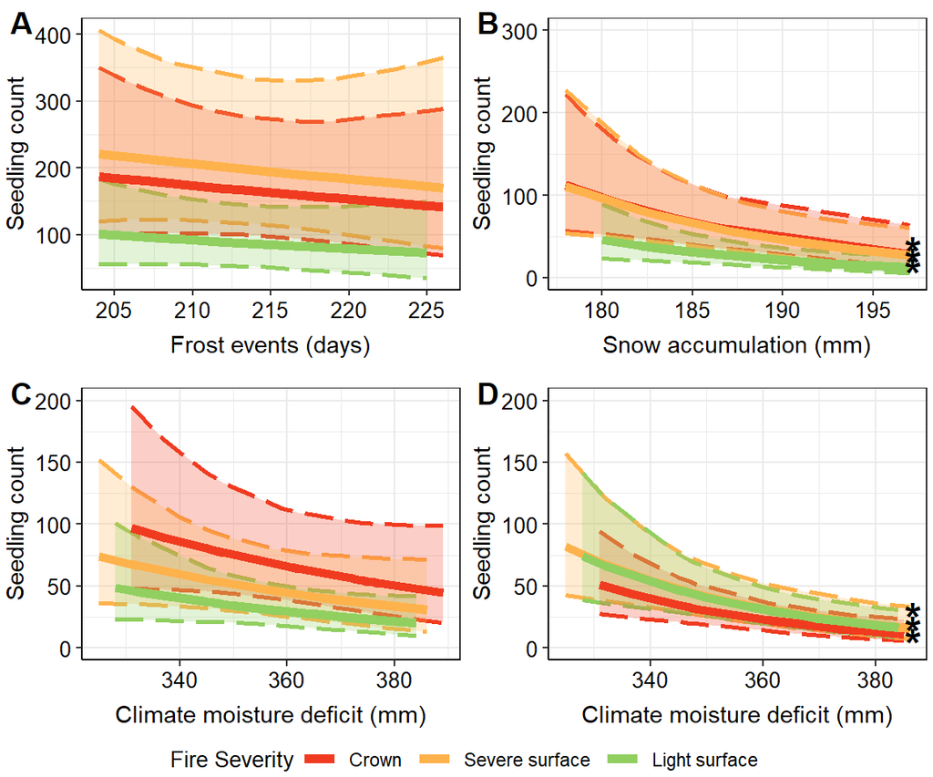